# STAT 425 Case Study 1 - Analysis of Red Wines dataset

10/20/2021

## Problem Statment : Red Wines Data Analysis

In the homework, you have already studied a white wines data set. In this case study, we have a similar data set available. It is related to the red variant of the Portuguese ”Vinho Verde” wine.

The variables we have available are the following:

X1: fixed acidity

X2: volatile acidity

X3: citric acid

X4: residual sugar

X5: chlorides

X6: free sulfur dioxide

X7: total sulfur dioxide

X8: density

X9: pH

X10: sulphates

Y : alcohol

Our goal is to fit a model to describe the association between alcohol and physiochemical information (potential predictors X1-X10). The data can be found in the redwines.csv data set on Moodle.

## Analysis Steps :

### Step 0 : Loading Required Libraries

```r
library(dplyr)
library(faraway)
library(lmtest)
library(MASS)

library(car)
```

### Step 1 : Reading the data

Let us first read the data and go through the required columns :

```r
rw.data = read.csv("redwines.csv", header=TRUE)
names(rw.data)
```

```
##  [1] "fixed.acidity"        "volatile.acidity"     "citric.acid"
##  [4] "residual.sugar"       "chlorides"            "free.sulfur.dioxide"
##  [7] "total.sulfur.dioxide" "density"              "pH"
## [10] "sulphates"            "alcohol"              "quality"
```

We observe that there is an extra variable `quality` which is not part of our problem statement. So, we will be dropping this variable before proceeding further in the analysis.

```r
rw.new=rw.data[,!(names(rw.data)=='quality')]
names(rw.new)
```

```
##  [1] "fixed.acidity"        "volatile.acidity"     "citric.acid"
##  [4] "residual.sugar"       "chlorides"            "free.sulfur.dioxide"
##  [7] "total.sulfur.dioxide" "density"              "pH"
## [10] "sulphates"            "alcohol"
```

```r
dim(rw.new)
```

```
## [1] 1599   11
```

We will be working with rw.new from here on.

Let’s look at the first few rows of the dataset and the summary of the dataset:

```r
head(rw.new)
```

```
##   fixed.acidity volatile.acidity citric.acid residual.sugar chlorides
## 1           7.4             0.70        0.00            1.9     0.076
## 2           7.8             0.88        0.00            2.6     0.098
## 3           7.8             0.76        0.04            2.3     0.092
## 4          11.2             0.28        0.56            1.9     0.075
## 5           7.4             0.70        0.00            1.9     0.076
## 6           7.4             0.66        0.00            1.8     0.075
##   free.sulfur.dioxide total.sulfur.dioxide density   pH sulphates alcohol
## 1                  11                   34  0.9978 3.51      0.56     9.4
## 2                  25                   67  0.9968 3.20      0.68     9.8
## 3                  15                   54  0.9970 3.26      0.65     9.8
## 4                  17                   60  0.9980 3.16      0.58     9.8
## 5                  11                   34  0.9978 3.51      0.56     9.4
## 6                  13                   40  0.9978 3.51      0.56     9.4
```

```r
summary(rw.new)
```

```
##  fixed.acidity   volatile.acidity  citric.acid    residual.sugar
##  Min.   : 4.60   Min.   :0.1200   Min.   :0.000   Min.   : 0.900
##  1st Qu.: 7.10   1st Qu.:0.3900   1st Qu.:0.090   1st Qu.: 1.900
##  Median : 7.90   Median :0.5200   Median :0.260   Median : 2.200
##  Mean   : 8.32   Mean   :0.5278   Mean   :0.271   Mean   : 2.539
##  3rd Qu.: 9.20   3rd Qu.:0.6400   3rd Qu.:0.420   3rd Qu.: 2.600
##  Max.   :15.90   Max.   :1.5800   Max.   :1.000   Max.   :15.500
##    chlorides       free.sulfur.dioxide total.sulfur.dioxide    density
##  Min.   :0.01200   Min.   : 1.00       Min.   :  6.00       Min.   :0.9901
##  1st Qu.:0.07000   1st Qu.: 7.00       1st Qu.: 22.00       1st Qu.:0.9956
##  Median :0.07900   Median :14.00       Median : 38.00       Median :0.9968
##  Mean   :0.08747   Mean   :15.87       Mean   : 46.47       Mean   :0.9967
##  3rd Qu.:0.09000   3rd Qu.:21.00       3rd Qu.: 62.00       3rd Qu.:0.9978
##  Max.   :0.61100   Max.   :72.00       Max.   :289.00       Max.   :1.0037
##        pH          sulphates         alcohol
##  Min.   :2.740   Min.   :0.3300   Min.   : 8.40
##  1st Qu.:3.210   1st Qu.:0.5500   1st Qu.: 9.50
##  Median :3.310   Median :0.6200   Median :10.20
##  Mean   :3.311   Mean   :0.6581   Mean   :10.42
##  3rd Qu.:3.400   3rd Qu.:0.7300   3rd Qu.:11.10
##  Max.   :4.010   Max.   :2.0000   Max.   :14.90
```

Upon observation, all the variables in the dataset are numerical variables.

### Step 2 : Checking for linear correlation

Now, we will check how the predictors are linearly related to each other and how the predictors are linearly related to our response `alcohol`.

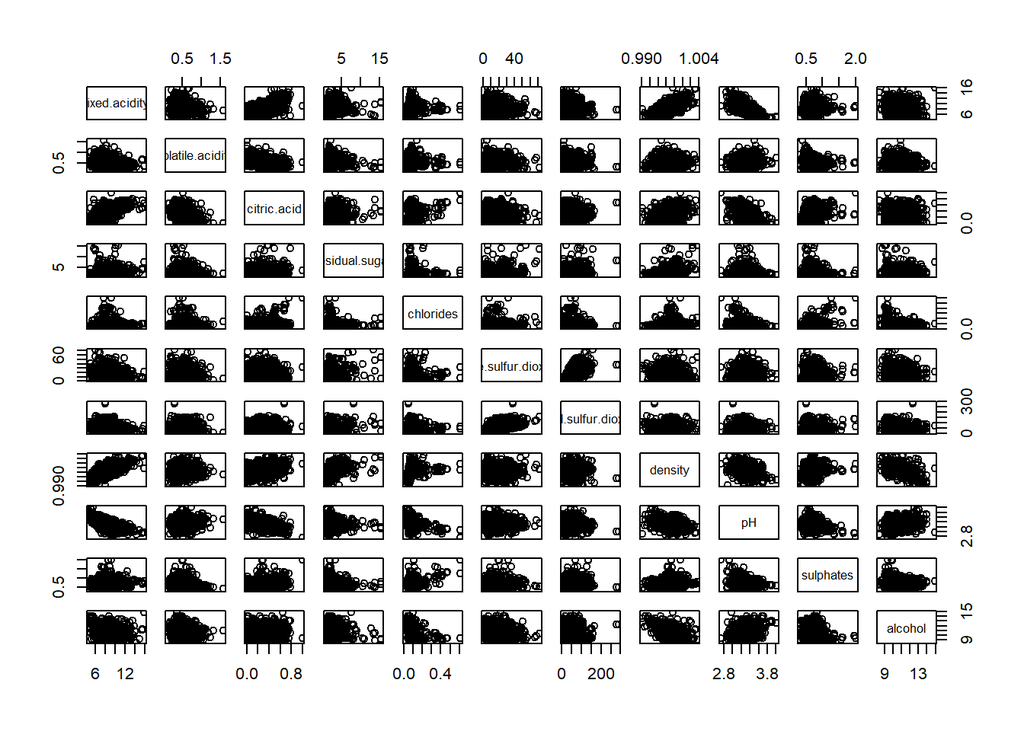

```r
pairs(rw.new)
```

```r
cor(rw.new)
```

```
##                      fixed.acidity volatile.acidity citric.acid residual.sugar
## fixed.acidity           1.00000000     -0.256130895  0.67170343    0.114776724
## volatile.acidity       -0.25613089      1.000000000 -0.55249568    0.001917882
## citric.acid             0.67170343     -0.552495685  1.00000000    0.143577162
## residual.sugar          0.11477672      0.001917882  0.14357716    1.000000000
## chlorides               0.09370519      0.061297772  0.20382291    0.055609535
## free.sulfur.dioxide    -0.15379419     -0.010503827 -0.06097813    0.187048995
## total.sulfur.dioxide   -0.11318144      0.076470005  0.03553302    0.203027882
## density                 0.66804729      0.022026232  0.36494718    0.355283371
## pH                     -0.68297819      0.234937294 -0.54190414   -0.085652422
## sulphates               0.18300566     -0.260986685  0.31277004    0.005527121
## alcohol                -0.06166827     -0.202288027  0.10990325    0.042075437
##                         chlorides free.sulfur.dioxide total.sulfur.dioxide
## fixed.acidity         0.093705186        -0.153794193          -0.11318144
## volatile.acidity      0.061297772        -0.010503827           0.07647000
## citric.acid           0.203822914        -0.060978129           0.03553302
## residual.sugar        0.055609535         0.187048995           0.20302788
## chlorides             1.000000000         0.005562147           0.04740047
## free.sulfur.dioxide   0.005562147         1.000000000           0.66766645
## total.sulfur.dioxide  0.047400468         0.667666450           1.00000000
## density               0.200632327        -0.021945831           0.07126948
## pH                   -0.265026131         0.070377499          -0.06649456
## sulphates             0.371260481         0.051657572           0.04294684
## alcohol              -0.221140545        -0.069408354          -0.20565394
##                          density          pH    sulphates     alcohol
## fixed.acidity         0.66804729 -0.68297819  0.183005664 -0.06166827
## volatile.acidity      0.02202623  0.23493729 -0.260986685 -0.20228803
## citric.acid           0.36494718 -0.54190414  0.312770044  0.10990325
## residual.sugar        0.35528337 -0.08565242  0.005527121  0.04207544
## chlorides             0.20063233 -0.26502613  0.371260481 -0.22114054
## free.sulfur.dioxide  -0.02194583  0.07037750  0.051657572 -0.06940835
## total.sulfur.dioxide  0.07126948 -0.06649456  0.042946836 -0.20565394
## density               1.00000000 -0.34169933  0.148506412 -0.49617977
## pH                   -0.34169933  1.00000000 -0.196647602  0.20563251
## sulphates             0.14850641 -0.19664760  1.000000000  0.09359475
## alcohol              -0.49617977  0.20563251  0.093594750  1.00000000
```

Most of these relationships are not either strongly positively or negatively correlated, but we observe a couple of clear relationships. Based on the pair wise scatter plot and the pair wise correlation matrix above, we can make the following observations :

The response `alcohol` has both positive linear relationship as well as negative linear relationship with the different predictors. Most of the relationships are not that strong; for example, the maximum absolute linear correlation of ‘alcohol’ is with `density`, which has a negative correlation coefficient of 0.49.

Among the predictors the following have a slight linear relationship with each other indicating the presence of some degree of multi-collinearity.

1.fixed.acidity with citric.acid (correlation coefficient = 0.67)

2.volatile.acidity with citric.acid (correlation coefficient = -0.55)

3.fixed.acidity with density (correlation coefficient = 0.67)

4.fixed.acidity with pH (correlation coefficient = -0.68)

5.citric.acid with pH (correlation coefficient = -0.54)

6. free.sulfur.dioxide with total.sulfur.dioxide (correlation coefficient = 0.67)

## Step 3 : Fit the response with all available variables

Lets us fit the full model i.e. model with all the predictors and look at the significance of each predictor in explaining the variation in the response `alcohol`.

```r
full.model =  lm(alcohol ~ ., data=rw.new)
summary(full.model)
```

```
##
## Call:
## lm(formula = alcohol ~ ., data = rw.new)
##
## Residuals:
##      Min       1Q   Median       3Q      Max
## -2.07175 -0.39267 -0.04056  0.35396  2.44365
##
## Coefficients:
##                        Estimate Std. Error t value Pr(>|t|)
## (Intercept)           6.072e+02  1.308e+01  46.419  < 2e-16 ***
## fixed.acidity         5.324e-01  2.064e-02  25.796  < 2e-16 ***
## volatile.acidity      3.608e-01  1.144e-01   3.154 0.001638 **
## citric.acid           8.306e-01  1.379e-01   6.024 2.11e-09 ***
## residual.sugar        2.844e-01  1.229e-02  23.135  < 2e-16 ***
## chlorides            -1.462e+00  3.956e-01  -3.696 0.000227 ***
## free.sulfur.dioxide  -2.143e-03  2.057e-03  -1.042 0.297517
## total.sulfur.dioxide -2.296e-03  6.881e-04  -3.336 0.000868 ***
## density              -6.174e+02  1.342e+01 -45.998  < 2e-16 ***
## pH                    3.762e+00  1.551e-01  24.263  < 2e-16 ***
## sulphates             1.247e+00  1.037e-01  12.020  < 2e-16 ***
## ---
## Signif. codes:  0 '***' 0.001 '**' 0.01 '*' 0.05 '.' 0.1 ' ' 1
##
## Residual standard error: 0.614 on 1588 degrees of freedom
## Multiple R-squared:  0.6701, Adjusted R-squared:  0.668
## F-statistic: 322.5 on 10 and 1588 DF,  p-value: < 2.2e-16
```

From the model summary ,we can see that the $R^2$ is around ~67% which is considered to be decent.

The overall p-value of F-test is smaller than our significance level of 5% which means that the model does have at least one predictor with a non-zero regression coefficient.

Also, there apart from `free.sulfur.dioxide`, all other predictors are statistically significant at a significance level of 5%.

## Step 4 : Checking for the presence of multicollinearity

Let’s check the presence of multicollinearity before we decide to drop any non-significant variable from the dataset.

Firstly, let’s check the condition number:

```r
#Standardising the model matrix:
x = model.matrix(full.model)[,-1]
x = x - matrix(apply(x,2, mean), 1599,10, byrow=TRUE)
x = x / matrix(apply(x, 2, sd), 1599,10, byrow=TRUE)
#Extracting the eigen-values:
e = eigen(t(x) %*% x)
sqrt(max(e$val)/min(e$val))
```

```
## [1] 5.426282
```

The condition number is smaller than 30. So we conclude that collinearity is not present in the dataset.

To double check, we can also see the variance inflation factor (VIF) of the individual predictors to determine whether any one of them should be removed to reduce collinearity.

```r
vif(full.model)
```

```
##        fixed.acidity     volatile.acidity          citric.acid
##             5.473788             1.778247             3.058141
##       residual.sugar            chlorides  free.sulfur.dioxide
##             1.273397             1.469296             1.961678
## total.sulfur.dioxide              density                   pH
##             2.171590             2.719873             2.429220
##            sulphates
##             1.310219
```

All the variables have VIF significantly less than 10 suggesting that collinearity is not present.

## Step 5 : Fit Reduced Model and Check Significance using ANOVA

We can determine the difference between the full and reduced models using ANOVA. From the regression summary of the full model, we can see that `free.sulfur.dioxide` is not statistically significant. We can remove that predictor and fit a reduced model to our response `alcohol`. Further more we can check if the reduced model is adequate in explaining the variation in response or not.

```r
rw.reduced <-  lm(alcohol ~ fixed.acidity+volatile.acidity+citric.acid+residual.sugar+chlorides+total.sulfur.dioxide+density+pH+sulphates, data=rw.new)
summary(rw.reduced)
```

```
##
## Call:
## lm(formula = alcohol ~ fixed.acidity + volatile.acidity + citric.acid +
##     residual.sugar + chlorides + total.sulfur.dioxide + density +
##     pH + sulphates, data = rw.new)
##
## Residuals:
##      Min       1Q   Median       3Q      Max
## -2.06145 -0.39706 -0.03917  0.34928  2.44848
##
## Coefficients:
##                        Estimate Std. Error t value Pr(>|t|)
## (Intercept)           6.059e+02  1.302e+01  46.535  < 2e-16 ***
## fixed.acidity         5.300e-01  2.051e-02  25.846  < 2e-16 ***
## volatile.acidity      3.809e-01  1.128e-01   3.377 0.000749 ***
## citric.acid           8.548e-01  1.359e-01   6.289 4.12e-10 ***
## residual.sugar        2.827e-01  1.219e-02  23.198  < 2e-16 ***
## chlorides            -1.487e+00  3.949e-01  -3.766 0.000172 ***
## total.sulfur.dioxide -2.775e-03  5.123e-04  -5.416 7.02e-08 ***
## density              -6.160e+02  1.335e+01 -46.125  < 2e-16 ***
## pH                    3.739e+00  1.534e-01  24.369  < 2e-16 ***
## sulphates             1.242e+00  1.036e-01  11.984  < 2e-16 ***
## ---
## Signif. codes:  0 '***' 0.001 '**' 0.01 '*' 0.05 '.' 0.1 ' ' 1
##
## Residual standard error: 0.614 on 1589 degrees of freedom
## Multiple R-squared:  0.6699, Adjusted R-squared:  0.668
## F-statistic: 358.2 on 9 and 1589 DF,  p-value: < 2.2e-16
```

We can see that all the 9 predictors in the model are statistically significant ( i.e. the null hypothesis $H_0 : \beta_j =0$ can be rejected for any predictor $X_j$ where j=1,2,…9)

Let’s check if this model is better than the full model using the ANOVA test.

```r
anova(rw.reduced,full.model)
```

```
## Analysis of Variance Table
##
## Model 1: alcohol ~ fixed.acidity + volatile.acidity + citric.acid + residual.sugar +
##     chlorides + total.sulfur.dioxide + density + pH + sulphates
## Model 2: alcohol ~ fixed.acidity + volatile.acidity + citric.acid + residual.sugar +
##     chlorides + free.sulfur.dioxide + total.sulfur.dioxide +
##     density + pH + sulphates
##   Res.Df    RSS Df Sum of Sq     F Pr(>F)
## 1   1589 599.11
## 2   1588 598.70  1   0.40944 1.086 0.2975
```

Since the p value is > 0.05, we fail to reject the null hypothesis that the reduced model is adequate. (i.e $H_0$: Reduced Model is sufficient in explaining the variation in `alcohol`).

Therefore, we can move forward with using the reduced model and checking the model diagnostics.

## Step 6 : Model Diagnostics

We will now check if our preferred model is “good” by testing its validity.

### 6.(a) Checking for Unusual Observations

Let’s check for unusual observations in our model which might impact the regression structure in our model. High leverage points or outliers must be carefully considered since these points can have disproportionate effects on the overall pattern of the data. Therefore, if any of these are present, we may need to consider that in any final results or possibly remove data.

#### 6(a)(i) Checking for the presence of high leverage points

First, let us check for the presence of high leverage points in the dataset.

```r
n=dim(rw.new)[1]; # sample size
p=10; # 9 predictors plus intercept

# Compute Leverages
lev=influence(rw.reduced)$hat

# Determine which exceed the 2p/n threshold
newlev = lev[lev>2*p/n]
length(newlev)
```

```
## [1] 113
```

```r
length(newlev)/n
```

```
## [1] 0.07066917
```

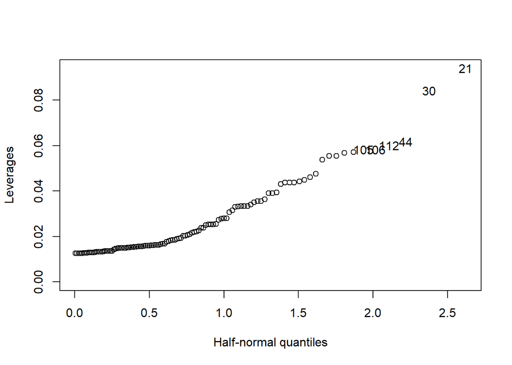

```r
# Prepare a half-normal plot
halfnorm(newlev, 6, labs=as.character(1:length(newlev)), ylab="Leverages")
```

#### 6(a)(ii) Checking for the presence of outliers

We can now check for outliers in the dataset using Bonferroni’s correction.

```r
jackknife=rstudent(rw.reduced)
n = 1599
p = 9
#Significance level adjusted with Bonferroni's Correction
x=qt(.05/(2*n), n-p-1)
x
```

```
## [1] -4.176063
```

```r
sort(abs(jackknife),decreasing =T)[1:10]
```

```
##      652      560      565      396      354      557      559      494
## 4.038199 4.018534 4.018534 3.952545 3.858127 3.694477 3.694477 3.670237
##      500      268
## 3.670237 3.455404
```

We can see that there are no outliers in the dataset i.e there are no studentized residual values that are higher (in absolute value) of the critical T distribution value with Bonferroni’s correction.

#### 6(a)(iii) Checking for the presence of High Influential Points

To detect high influential points, let’s check the cook’s distance for our model:

```r
cook = cooks.distance(rw.reduced)
# Extract max Cook's Distance
max(cook)
```

```
## [1] 0.07210158
```

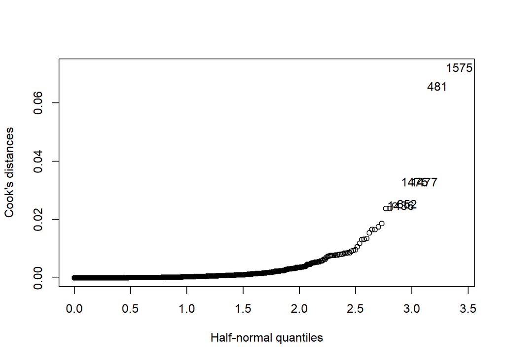

```r
halfnorm(cook, 6, labs=as.character(1:length(cook)), ylab="Cook's distances")
```

From the outputs above, we can see that there no datapoints with a Cook’s distance higher than 1. Therefore, by this rule of thumb, we can conclude that there are no high influential points. Through all the work done in 6 (a), we can conclude that there are **no high influential points**; therefore, we do not need to remove any data points from our dataset or account for any data that may skew our results.

### 6.(b) Checking for Model Assumptions

Now, we need to check if there are violations of basic assumptions of our model. The three that we will be focusing on are potential violations of the normality, constant variance, and linearity assumptions.

#### 6(b)(i) Checking the constant variance assumption (Homoscedasticity)

We can check whether the residuals have constant variance with respect to the fitted values in our model. We would use our reduced model and evaluate the constant variance assumption by viewing the behavior of the data around the zero line.

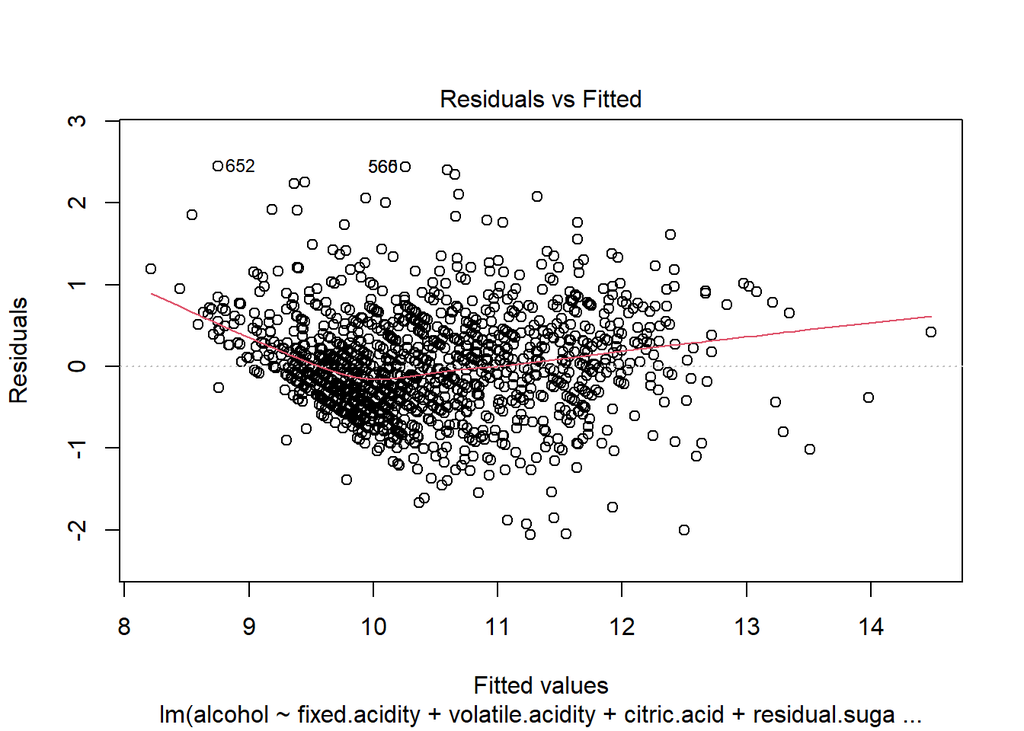

```r
plot(rw.reduced, which=1)
```

From the residuals versus the fitted values plot, it is observed that there is significant deviation from the constant variance assumption. We can confirm this by performing the Breusch-Pagan test to check for heteroscedasticity.

```r
bptest(rw.reduced)
```

```
##
##  studentized Breusch-Pagan test
##
## data:  rw.reduced
## BP = 169.31, df = 9, p-value < 2.2e-16
```

Since the p-value is much less than our 5% significance level, we have to reject the null hypothesis that the errors have constant variance and conclude that the constant variance assumption of our model is violated.

#### 6(b)(ii) Checking the normality of errors assumption

In order to check if the errors in our model are normally distributed around a mean of zero, we need to look at the histogram of the residuals:

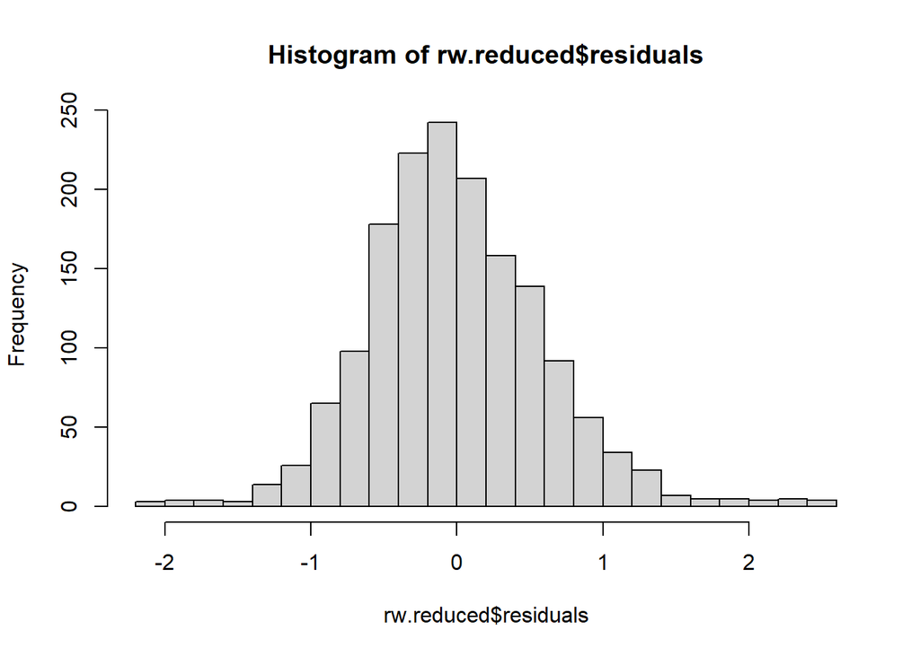

```r
hist(rw.reduced$residuals, breaks = 20)
```

The histogram above suggests that the residuals are slightly skewed to the right, which means that we can predict that the mean is not equal to zero.

Let’s look at the Q-Q plot to see whether we can observe a straight line.

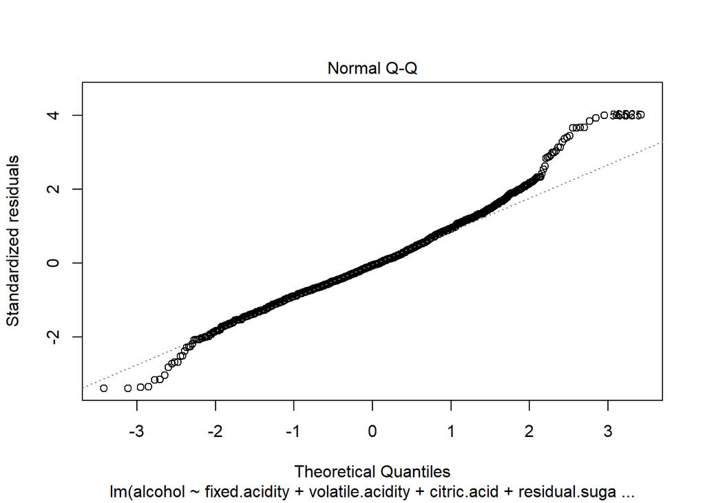

```r
plot(rw.reduced, which=2)
```

We can observe a significant deviation from the straight line for points with lower and higher theoretical quantiles. This again suggests that the residuals are not normally distributed.

To confirm this , we can perform the Kolmogorov-Smirnov test to test for normality:

```r
ks.test(residuals(rw.reduced), y=pnorm)
```

```
##
##  One-sample Kolmogorov-Smirnov test
##
## data:  residuals(rw.reduced)
## D = 0.14307, p-value < 2.2e-16
## alternative hypothesis: two-sided
```

Since the p-value obtained from the KS test is much lower than our 5% significance level, we should reject the null hypothesis that the errors are normally distributed and conclude that the Normality assumption is violated.

Since the normality assumption is violated, our test for statistically significant predictors can’t be based on t-tests and F-tests. In this case, we need to do the Permutation test on the full model with shuffling the values of the predictor we think is insignificant. Therefore, we need to do Permutation Test to ascertain that the `free.sulfur.dioxide` predictor that we removed from the model, is indeed not significant.

Under the null hypothesis, we have $H_0$: $\beta_{free.sulfur.dioxide} = 0$; alternatively, $H_1$ = $\beta_{free.sulfur.dioxide}$ is *not* 0.

We then calculate the p-value using Monte-Carlo method with the decision rule that if the obtained p-value is less than $\alpha$ = 0.05, we can reject the null hypothesis:

```r
set.seed(1)
n = dim(rw.new)[1]
n.iter = 2000;
fstats = numeric(n.iter)
for (i in 1:n.iter){
  rw.new1 = rw.new
  rw.new1[, 6] = rw.new[sample(n), 6] #6th column pertaining to free.sulfur.dioxide
  reg = lm(alcohol ~., data = rw.new1)
  fstats[i] = summary(reg)$fstat[1]
}
p.value = length(fstats[fstats>summary(full.model)$fstat[1]])/n.iter
p.value
```

```
## [1] 0.311
```

Since the p-value is 0.31, we fail to reject the null hypothesis and conclude that the model without the `free.sulfur.dioxide` as one of the predictors, is an adequate one.

#### 6(b)(iii) Checking the linearity assumption

We can check linearity from the added variable plots of our model:

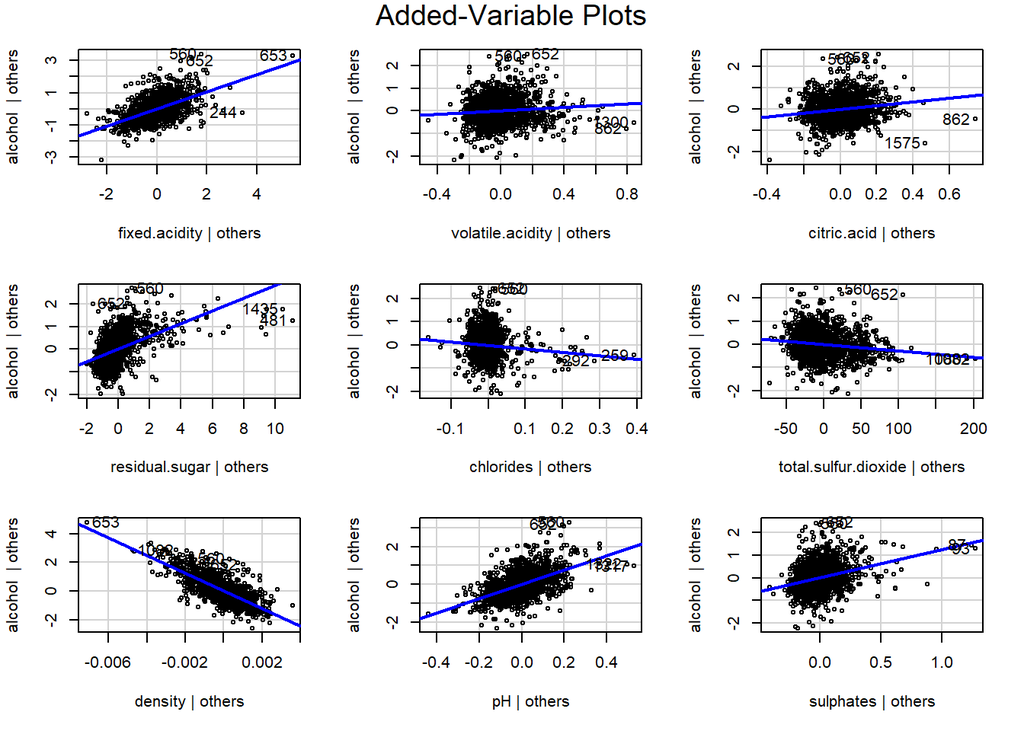

```r
avPlots(rw.reduced)
```

For all the predictors, the added variable plot suggests that the residuals are scattered around a straight line and therefore linearity condition is satisfied and we don’t need to transform any predictor.

From the above outputs we can observe that our **Normality and Constant Variance assumptions are violated**. As a remedial measure, we can look into transforming our response and refitting the model.

## Step 7 : Box-Cox Transformation

To utilize Box-Cox transformation as a remedial measure , we need to find the value of $\hat\lambda$ which maximizes the likelihood of observing our dataset. But, first we need to check if their is any zero or negative value in our response, since the Box-Cox method does not work on such values.

```r
min(rw.new$alcohol)
```

```
## [1] 8.4
```

Since the minimum value of our response is 8.4, we are good to go with the finding the $\hat\lambda$.

```r
model.transformation = boxcox(rw.reduced, lambda=seq(-2, 2, length=400))
```

[figure not shown]

```r
model.transformation$x[model.transformation$y==max(model.transformation$y)]
```

```
## [1] -1.528822
```

```r
tmp=model.transformation$x[model.transformation$y>max(model.transformation$y)-qchisq(0.95,1)/2]

range(tmp)
```

```
## [1] -1.949875 -1.117794
```

As can be seen from the plot, the 95% Confidence Interval of $\hat\lambda$ does not contain 1. Thus, a transformation of the response is recommended. Let’s check the for the optimum transformation.

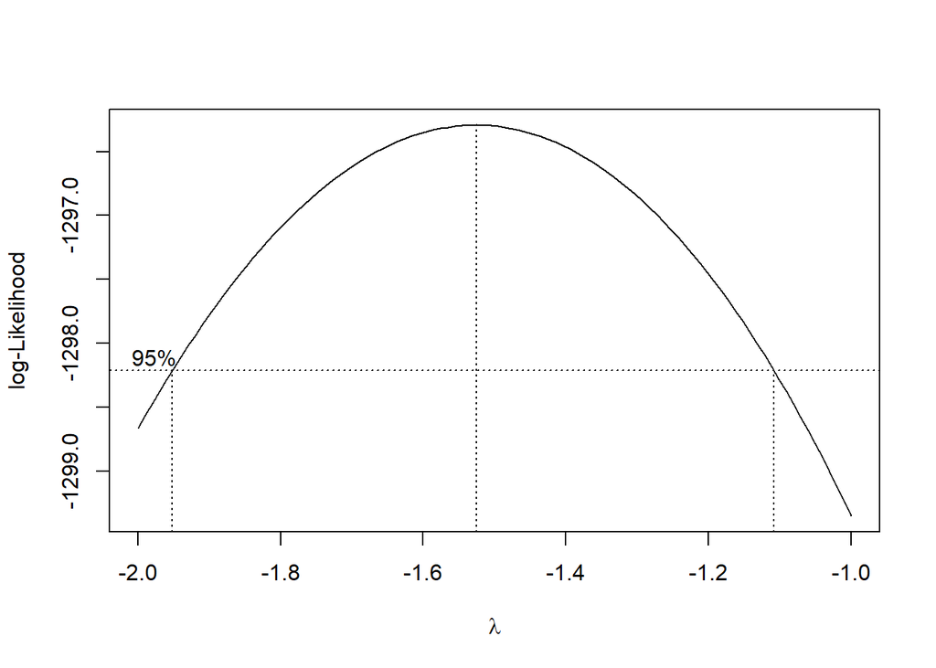

```r
boxcox(rw.reduced,plotit=T,lambda=seq(-2,-1,by=0.025)) # zoom-in
```

Since $\lambda=-1.5$ is close to the optimum value which maximizes the log-likelihood, we can use this $\lambda$ to transform the response and fit a new model using the transformed response and all the predictors.

```r
p=-1.5

rw.new$alc_trans<-(rw.new$alcohol)**(p)

rw.transformed<-lm(alc_trans~ fixed.acidity+free.sulfur.dioxide+volatile.acidity+citric.acid+residual.sugar+chlorides+total.sulfur.dioxide+density+pH+sulphates, data=rw.new)

summary(rw.transformed)
```

```
##
## Call:
## lm(formula = alc_trans ~ fixed.acidity + free.sulfur.dioxide +
##     volatile.acidity + citric.acid + residual.sugar + chlorides +
##     total.sulfur.dioxide + density + pH + sulphates, data = rw.new)
##
## Residuals:
##        Min         1Q     Median         3Q        Max
## -0.0103017 -0.0016016  0.0000113  0.0016319  0.0090948
##
## Coefficients:
##                        Estimate Std. Error t value Pr(>|t|)
## (Intercept)          -2.290e+00  5.401e-02 -42.402  < 2e-16 ***
## fixed.acidity        -2.099e-03  8.522e-05 -24.632  < 2e-16 ***
## free.sulfur.dioxide  -1.255e-07  8.492e-06  -0.015 0.988209
## volatile.acidity     -1.584e-03  4.723e-04  -3.354 0.000817 ***
## citric.acid          -3.320e-03  5.693e-04  -5.832 6.62e-09 ***
## residual.sugar       -1.095e-03  5.076e-05 -21.577  < 2e-16 ***
## chlorides             7.502e-03  1.633e-03   4.593 4.71e-06 ***
## total.sulfur.dioxide  1.352e-05  2.841e-06   4.760 2.12e-06 ***
## density               2.402e+00  5.542e-02  43.336  < 2e-16 ***
## pH                   -1.487e-02  6.402e-04 -23.219  < 2e-16 ***
## sulphates            -5.120e-03  4.283e-04 -11.955  < 2e-16 ***
## ---
## Signif. codes:  0 '***' 0.001 '**' 0.01 '*' 0.05 '.' 0.1 ' ' 1
##
## Residual standard error: 0.002535 on 1588 degrees of freedom
## Multiple R-squared:  0.6513, Adjusted R-squared:  0.6491
## F-statistic: 296.6 on 10 and 1588 DF,  p-value: < 2.2e-16
```

We can see that apart from the predictor `free.sulfur.dioxide`, all other predictors are statistically significant. We can also observe that the $R^2$ has reduced to 65% after the transformation.

Let’s remove `free.sulfur.dioxide` from our model and perform an ANOVA test.

```r
rw.trans.reduced<-lm(alc_trans~ fixed.acidity+volatile.acidity+citric.acid+residual.sugar+chlorides+total.sulfur.dioxide+density+pH+sulphates, data=rw.new)
summary(rw.trans.reduced)
```

```
##
## Call:
## lm(formula = alc_trans ~ fixed.acidity + volatile.acidity + citric.acid +
##     residual.sugar + chlorides + total.sulfur.dioxide + density +
##     pH + sulphates, data = rw.new)
##
## Residuals:
##        Min         1Q     Median         3Q        Max
## -0.0103015 -0.0016017  0.0000123  0.0016327  0.0090954
##
## Coefficients:
##                        Estimate Std. Error t value Pr(>|t|)
## (Intercept)          -2.290e+00  5.374e-02 -42.617  < 2e-16 ***
## fixed.acidity        -2.099e-03  8.464e-05 -24.804  < 2e-16 ***
## volatile.acidity     -1.583e-03  4.654e-04  -3.400 0.000689 ***
## citric.acid          -3.319e-03  5.610e-04  -5.916 4.04e-09 ***
## residual.sugar       -1.095e-03  5.030e-05 -21.774  < 2e-16 ***
## chlorides             7.501e-03  1.630e-03   4.603 4.51e-06 ***
## total.sulfur.dioxide  1.349e-05  2.114e-06   6.382 2.29e-10 ***
## density               2.402e+00  5.512e-02  43.571  < 2e-16 ***
## pH                   -1.487e-02  6.333e-04 -23.477  < 2e-16 ***
## sulphates            -5.120e-03  4.276e-04 -11.974  < 2e-16 ***
## ---
## Signif. codes:  0 '***' 0.001 '**' 0.01 '*' 0.05 '.' 0.1 ' ' 1
##
## Residual standard error: 0.002534 on 1589 degrees of freedom
## Multiple R-squared:  0.6513, Adjusted R-squared:  0.6493
## F-statistic: 329.7 on 9 and 1589 DF,  p-value: < 2.2e-16
```

```r
anova(rw.trans.reduced,rw.transformed)
```

```
## Analysis of Variance Table
##
## Model 1: alc_trans ~ fixed.acidity + volatile.acidity + citric.acid +
##     residual.sugar + chlorides + total.sulfur.dioxide + density +
##     pH + sulphates
## Model 2: alc_trans ~ fixed.acidity + free.sulfur.dioxide + volatile.acidity +
##     citric.acid + residual.sugar + chlorides + total.sulfur.dioxide +
##     density + pH + sulphates
##   Res.Df      RSS Df  Sum of Sq     F Pr(>F)
## 1   1589 0.010206
## 2   1588 0.010206  1 1.4042e-09 2e-04 0.9882
```

The p-value of the anova test is greater than the significance level of 5% and therefore we fail to reject the null hypothesis that the reduced model is adequate in explaining the variation in the response.

In order to ascertain whether the significance of the predictor is found correctly, we can look at the normality assumption once again.

```r
#Kolmogorov-Smirnov Test on the residuals from the transformed model:
ks.test(residuals(rw.transformed), y = pnorm)
```

```
##
##  One-sample Kolmogorov-Smirnov test
##
## data:  residuals(rw.transformed)
## D = 0.49637, p-value < 2.2e-16
## alternative hypothesis: two-sided
```

Since the p-value is less than 0.05, we can reject the null hypothesis that the errors are normally distributed. Thus, the normality assumption is violated. We nee to do a permutation test to check for statistical significance of the predictor we found insignificant. Our null hypothesis is that the predictor `free.sulfur.dioxide` is not significant.

```r
n = dim(rw.new)[1]
n.iter = 2000;
fstats = numeric(n.iter)
for (i in 1:n.iter){
  rw.new2 = rw.new
  rw.new2[, 6] = rw.new[sample(n), 6] #6th column pertaining to free.sulfur.dioxide
  reg = lm(alc_trans ~fixed.acidity+free.sulfur.dioxide+volatile.acidity+citric.acid+residual.sugar+chlorides+total.sulfur.dioxide+density+pH+sulphates, data = rw.new2)
  fstats[i] = summary(reg)$fstat[1]
}
p.value = length(fstats[fstats>summary(rw.transformed)$fstat[1]])/n.iter
p.value
```

```
## [1] 0.987
```

As we can see the p-value is much larger than the significance level of 0.05. Thus, we can’t reject the null hypothesis that the predictor is insignificant. So, we go ahead with the reduced model.

So we will be moving forward with the reduced model with the transformed response (rw.trans.reduced)

## Step 8 : Model Diagnostics of the transformed model

As with any new model we need to perform diagnostics to check for unusual observations and check if any assumptions are being violated.

### Step 8(a) : Checking for unusual observations

#### 8(a)(i) Checking for the presence of high leverage points

Again, we can check our transformed model for high leverage points to ensure that no data point wll skew the results.

```r
n=dim(rw.new)[1]; # sample size
p=10; # 9 predictors plus intercept



# Compute Leverages
lev=influence(rw.trans.reduced)$hat

# Determine which exceed the 2p/n threshold
newlev = lev[lev>2*p/n]
length(newlev)
```

```
## [1] 113
```

```r
length(newlev)/n
```

```
## [1] 0.07066917
```

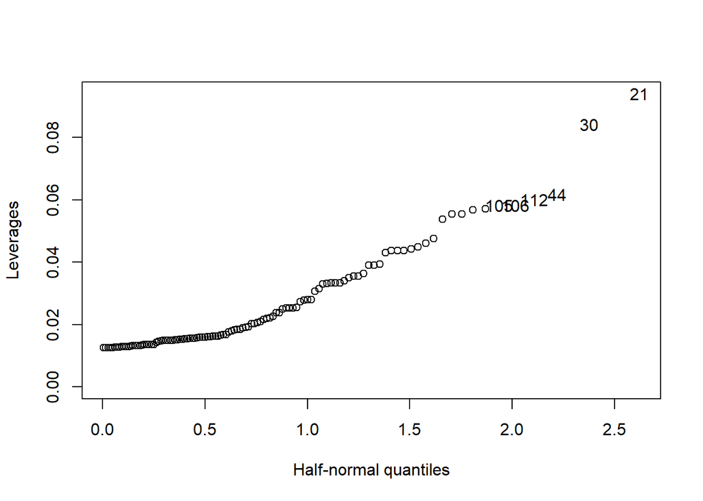

```r
# Prepare a half-normal plot
halfnorm(newlev, 6, labs=as.character(1:length(newlev)), ylab="Leverages")
```

As expected, the high leverage points do not change with our previous model as we are using the same set of predictors in this model as well.

#### 8(a)(ii) Checking for the presence of outliers

```r
jackknife=rstudent(rw.trans.reduced)
n = 1599
p = 9
x=qt(.05/(2*n), n-p-1)
x
```

```
## [1] -4.176063
```

```r
sort(abs(jackknife),decreasing =T)[1:10]
```

```
##      652      244      245      557      559      494      500      560
## 4.117132 3.639582 3.639582 3.607285 3.607285 3.607215 3.607215 3.452427
##      565      372
## 3.452427 3.424249
```

From the above, we can see that there are no outliers as there are no studentised residual values that are higher (in absolute value) of the critical T distribution value with Bonferroni’s correction.

#### 8(a)(iii) Checking for the presence of High Influential Points

```r
cook = cooks.distance(rw.trans.reduced)
# Extract max Cook's Distance
max(cook)
```

```
## [1] 0.07231543
```

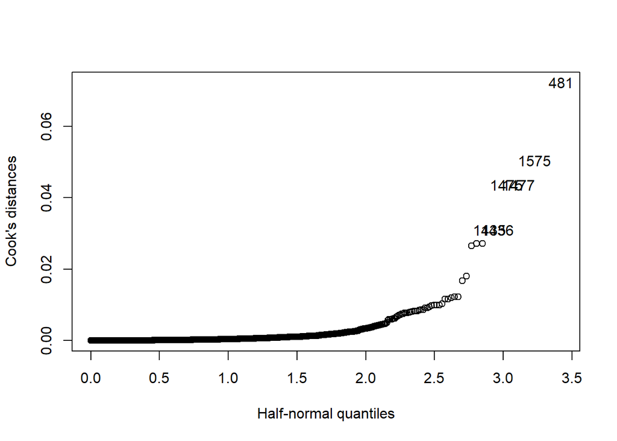

```r
halfnorm(cook, 6, labs=as.character(1:length(cook)), ylab="Cook's distances")
```

Since all the Cook’s distances are well less than 1, we can safely say that there are no high influential points in the dataset.

### 8.(b) Checking for Model Assumptions

We also need to see if there are any of the assumptions of our model are being violated.

#### 8(b)(i) Checking the constant variance assumption (Homoscedasticity)

Let’s check if the residuals have constant variance with respect to the fitted values in our model:

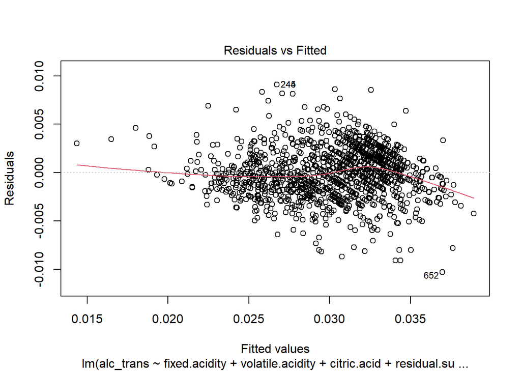

```r
plot(rw.trans.reduced, which=1)
```

The residuals have lower variance for lower and higher fitted values while they have higher variances in the middle. This suggests that the error variance is not constant. We can confirm this from Breusch-pagan Test.

```r
bptest(rw.trans.reduced)
```

```
##
##  studentized Breusch-Pagan test
##
## data:  rw.trans.reduced
## BP = 184.01, df = 9, p-value < 2.2e-16
```

Since the p-value is much less than our 5% significance level, we have to reject the null hypothesis that the errors have constant variance and conclude that the constant variance assumption of our model is violated.

#### 8(b)(ii) Checking the normality of errors assumption

Let’s check if the errors in our model are normally distributed around a mean of zero. In order to achieve this, we need to look at the histogram of the residuals:

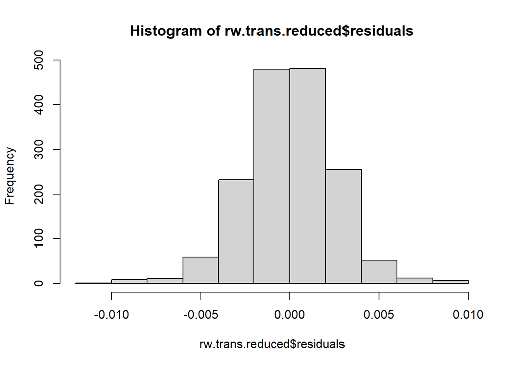

```r
hist(rw.trans.reduced$residuals)
```

There is an improvement in the normality of the residuals i.e. the residuals are less right skewed than our untransformed model. However, the improvement is still not enough, since the normality assumption still fails the Kolmogorov-Smirnov test. We can confirm this from the Kolmogorov-Smirnov Test and the QQ Plot.

Let’s look at the Q-Q plot to see whether we can observe a straight line.

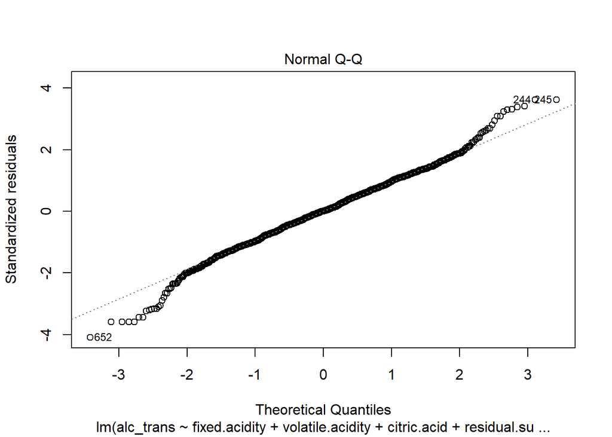

```r
plot(rw.trans.reduced, which=2)
```

We can observe a less deviation from the straight line for points with lower and higher theoretical quantiles as compared to the previous untransformed model. But, as seen above, the KS test still gives a p-value much lower than our 5% significance level, we have to reject the null hypothesis that the errors are normally distributed and conclude that the Normality assumption is violated .

#### 8(b)(iii) Checking the linearity assumption

We can check for linearity by looking at the output of our regression model itself.

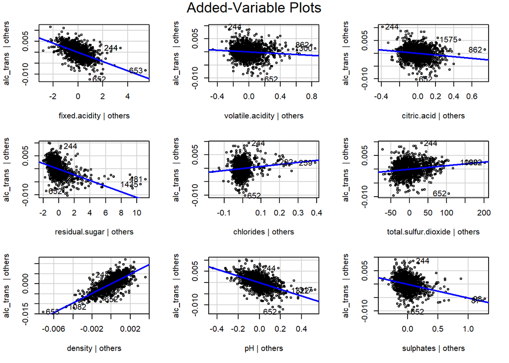

```r
#library(cars)
avPlots(rw.trans.reduced)
```

For all the predictors, the added variable plot suggests that the residuals are scattered around a straight line and therefore linearity condition is satisfied and we don’t need to transform any predictor.

From the above outputs we can observe that our Normality and Constant Variance assumptions are still violated even after transformation.

As an alternative, we can look into weighted least squares method for fitting our model.

## Step 9 : Weighted Least Squares method to fit the model

Since our residual variance is not constant, we can apply a weight to make it constant. Lets look at the relationship between the absolute residuals of our model and the predictors.

```r
lm.resid<-lm(abs(rw.reduced$residuals)~fixed.acidity+volatile.acidity+citric.acid+residual.sugar+density+pH+sulphates,data=rw.new)

summary(lm.resid)
```

```
##
## Call:
## lm(formula = abs(rw.reduced$residuals) ~ fixed.acidity + volatile.acidity +
##     citric.acid + residual.sugar + density + pH + sulphates,
##     data = rw.new)
##
## Residuals:
##      Min       1Q   Median       3Q      Max
## -0.77616 -0.26758 -0.06638  0.20882  1.87556
##
## Coefficients:
##                    Estimate Std. Error t value Pr(>|t|)
## (Intercept)       21.351218   7.706515   2.771  0.00566 **
## fixed.acidity      0.078048   0.011296   6.909 7.01e-12 ***
## volatile.acidity   0.117089   0.067064   1.746  0.08101 .
## citric.acid        0.136134   0.080175   1.698  0.08971 .
## residual.sugar     0.049542   0.007466   6.636 4.41e-11 ***
## density          -23.686831   7.868914  -3.010  0.00265 **
## pH                 0.532884   0.087527   6.088 1.43e-09 ***
## sulphates          0.133273   0.060119   2.217  0.02678 *
## ---
## Signif. codes:  0 '***' 0.001 '**' 0.01 '*' 0.05 '.' 0.1 ' ' 1
##
## Residual standard error: 0.3795 on 1591 degrees of freedom
## Multiple R-squared:  0.08284,    Adjusted R-squared:  0.0788
## F-statistic: 20.53 on 7 and 1591 DF,  p-value: < 2.2e-16
```

```r
#summary(rw.reduced)
```

Since the p-value from the regression summary is <5%, we can say there is some degree of linear relationship between the absolute residuals and the predictors.

The fitted values from the previous regression model will be used to calculate the weights in our WLS model.

$$w_i=\frac{1}{\hat s_i^2}$$

```r
rw.new$weight<-1/(lm.resid$fitted.values)^2

rw.wls<-lm(alcohol~fixed.acidity+volatile.acidity+residual.sugar+citric.acid+chlorides+total.sulfur.dioxide+density+pH+sulphates,data=rw.new,weights=weight)

summary(rw.wls)
```

```
##
## Call:
## lm(formula = alcohol ~ fixed.acidity + volatile.acidity + residual.sugar +
##     citric.acid + chlorides + total.sulfur.dioxide + density +
##     pH + sulphates, data = rw.new, weights = weight)
##
## Weighted Residuals:
##     Min      1Q  Median      3Q     Max
## -3.9857 -0.8529 -0.0726  0.7540  4.9307
##
## Coefficients:
##                        Estimate Std. Error t value Pr(>|t|)
## (Intercept)           6.315e+02  1.196e+01  52.821  < 2e-16 ***
## fixed.acidity         5.569e-01  1.959e-02  28.427  < 2e-16 ***
## volatile.acidity      8.807e-02  1.055e-01   0.835  0.40396
## residual.sugar        3.593e-01  1.564e-02  22.966  < 2e-16 ***
## citric.acid           5.514e-01  1.255e-01   4.393 1.19e-05 ***
## chlorides            -1.122e+00  3.423e-01  -3.280  0.00106 **
## total.sulfur.dioxide -2.124e-03  4.564e-04  -4.655 3.51e-06 ***
## density              -6.418e+02  1.226e+01 -52.331  < 2e-16 ***
## pH                    3.683e+00  1.344e-01  27.405  < 2e-16 ***
## sulphates             1.288e+00  9.166e-02  14.051  < 2e-16 ***
## ---
## Signif. codes:  0 '***' 0.001 '**' 0.01 '*' 0.05 '.' 0.1 ' ' 1
##
## Residual standard error: 1.269 on 1589 degrees of freedom
## Multiple R-squared:  0.7101, Adjusted R-squared:  0.7085
## F-statistic: 432.5 on 9 and 1589 DF,  p-value: < 2.2e-16
```

The $R_2$ has improved to 71% in the WLS model. Let’s check the variance covariance matrix of our previous model and new model to compare the coefficient variances.

```r
vcov(rw.reduced)
```

```
##                        (Intercept) fixed.acidity volatile.acidity   citric.acid
## (Intercept)           1.695305e+02  1.752912e-01     1.829570e-01 -0.2591873672
## fixed.acidity         1.752912e-01  4.204726e-04    -2.159841e-04 -0.0013665931
## volatile.acidity      1.829570e-01 -2.159841e-04     1.271665e-02  0.0079342836
## citric.acid          -2.591874e-01 -1.366593e-03     7.934284e-03  0.0184755071
## residual.sugar        5.923827e-02  5.146474e-05     5.536320e-06 -0.0002172499
## chlorides             1.211358e+00  2.712682e-03    -1.123880e-02 -0.0132843684
## total.sulfur.dioxide  1.287182e-03  3.619971e-06    -7.615159e-06 -0.0000136508
## density              -1.737158e+02 -1.856959e-01    -1.876653e-01  0.2671101407
## pH                    5.387782e-01  1.892698e-03    -9.771425e-04 -0.0005781291
## sulphates             5.411113e-02 -2.484502e-05     2.417044e-03 -0.0009366318
##                      residual.sugar     chlorides total.sulfur.dioxide
## (Intercept)            5.923827e-02  1.211358e+00         1.287182e-03
## fixed.acidity          5.146474e-05  2.712682e-03         3.619971e-06
## volatile.acidity       5.536320e-06 -1.123880e-02        -7.615159e-06
## citric.acid           -2.172499e-04 -1.328437e-02        -1.365080e-05
## residual.sugar         1.485404e-04  2.840629e-04        -6.858031e-07
## chlorides              2.840629e-04  1.559137e-01         2.521626e-05
## total.sulfur.dioxide  -6.858031e-07  2.521626e-05         2.624196e-07
## density               -6.068955e-02 -1.299744e+00        -1.389018e-03
## pH                     1.390376e-04  1.958411e-02         1.939612e-05
## sulphates              7.773197e-05 -1.406136e-02        -2.981700e-06
##                            density            pH     sulphates
## (Intercept)          -1.737158e+02  5.387782e-01  5.411113e-02
## fixed.acidity        -1.856959e-01  1.892698e-03 -2.484502e-05
## volatile.acidity     -1.876653e-01 -9.771425e-04  2.417044e-03
## citric.acid           2.671101e-01 -5.781291e-04 -9.366318e-04
## residual.sugar       -6.068955e-02  1.390376e-04  7.773197e-05
## chlorides            -1.299744e+00  1.958411e-02 -1.406136e-02
## total.sulfur.dioxide -1.389018e-03  1.939612e-05 -2.981700e-06
## density               1.783464e+02 -6.364768e-01 -5.923160e-02
## pH                   -6.364768e-01  2.353907e-02 -5.378345e-04
## sulphates            -5.923160e-02 -5.378345e-04  1.073382e-02
```

```r
vcov(rw.wls)
```

```
##                        (Intercept) fixed.acidity volatile.acidity
## (Intercept)           1.429396e+02  1.458156e-01     1.417360e-01
## fixed.acidity         1.458156e-01  3.837988e-04    -2.806062e-04
## volatile.acidity      1.417360e-01 -2.806062e-04     1.112898e-02
## residual.sugar        5.762801e-02  3.207709e-05    -6.872718e-05
## citric.acid          -1.875558e-01 -1.192989e-03     7.202865e-03
## chlorides             9.152038e-01  2.129700e-03    -9.905087e-03
## total.sulfur.dioxide  8.206907e-04  3.016913e-06    -6.563025e-06
## density              -1.464934e+02 -1.546498e-01    -1.429910e-01
## pH                    4.670137e-01  1.590652e-03    -1.312211e-03
## sulphates             7.434778e-02  9.219881e-06     1.638445e-03
##                      residual.sugar   citric.acid     chlorides
## (Intercept)            5.762801e-02 -1.875558e-01  9.152038e-01
## fixed.acidity          3.207709e-05 -1.192989e-03  2.129700e-03
## volatile.acidity      -6.872718e-05  7.202865e-03 -9.905087e-03
## residual.sugar         2.447287e-04 -2.065632e-04  3.174554e-04
## citric.acid           -2.065632e-04  1.575474e-02 -1.168300e-02
## chlorides              3.174554e-04 -1.168300e-02  1.171405e-01
## total.sulfur.dioxide  -8.202390e-07 -1.293134e-05  2.178057e-05
## density               -5.859690e-02  1.968772e-01 -9.827136e-01
## pH                     8.403125e-07 -1.187690e-03  1.519275e-02
## sulphates              6.290321e-05 -9.614786e-04 -1.122607e-02
##                      total.sulfur.dioxide       density            pH
## (Intercept)                  8.206907e-04 -1.464934e+02  4.670137e-01
## fixed.acidity                3.016913e-06 -1.546498e-01  1.590652e-03
## volatile.acidity            -6.563025e-06 -1.429910e-01 -1.312211e-03
## residual.sugar              -8.202390e-07 -5.859690e-02  8.403125e-07
## citric.acid                 -1.293134e-05  1.968772e-01 -1.187690e-03
## chlorides                    2.178057e-05 -9.827136e-01  1.519275e-02
## total.sulfur.dioxide         2.082581e-07 -9.110941e-04  1.843974e-05
## density                     -9.110941e-04  1.503932e+02 -5.421765e-01
## pH                           1.843974e-05 -5.421765e-01  1.806230e-02
## sulphates                   -1.912894e-06 -7.796195e-02 -5.513124e-04
##                          sulphates
## (Intercept)           7.434778e-02
## fixed.acidity         9.219881e-06
## volatile.acidity      1.638445e-03
## residual.sugar        6.290321e-05
## citric.acid          -9.614786e-04
## chlorides            -1.122607e-02
## total.sulfur.dioxide -1.912894e-06
## density              -7.796195e-02
## pH                   -5.513124e-04
## sulphates             8.401599e-03
```

## Step 10 : Model Assumption for WLS model

Multiple iterations of the model will best inform us which model is “best.” Hence, we’re testing model diagnostics and assumptions once again with the WLS model, attempting to improve our model as much as possible.

### Constant Variance

From the BP test, we can view whether the constant variance assumption is violated:

```r
bptest(rw.wls)
```

```
##
##  studentized Breusch-Pagan test
##
## data:  rw.wls
## BP = 169.31, df = 9, p-value < 2.2e-16
```

So the constant variance assumption is still violated.

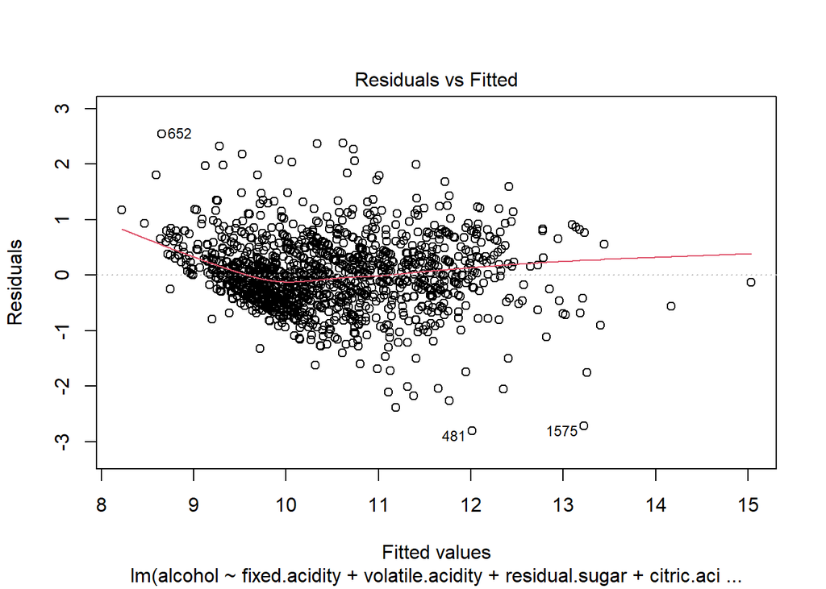

```r
plot(rw.wls, which=1)
```

### Normality

We can check the status of the Normality assumption using the KS test once again:

```r
ks.test(residuals(rw.wls),y=pnorm)
```

```
##
##  One-sample Kolmogorov-Smirnov test
##
## data:  residuals(rw.wls)
## D = 0.15111, p-value < 2.2e-16
## alternative hypothesis: two-sided
```

Due to the small p-value, the null hypothesis (that errors are normally distributed) can be rejected. Therefore, the normality assumption is also violated.

### Linearity

We can check the linearity assumption after noticing that the constant variance & normality assumptions are violated.

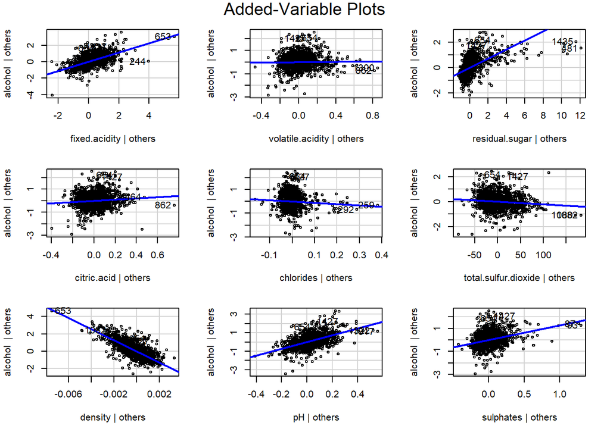

```r
avPlots(rw.wls)
```

The predictors seem to have a linear relationship with the response as the added variable plots seem to be linear in nature and this suggests that there is no transformation needed for the predictors.

In the steps to apply WLS estimates, we did not know the actual residual variances, which we estimated by fitting a linear regression model on absolute value of residuals versus the predictors, and extracting the fitted values. Since the constant variance assumption is still violated, we may iterate over the above steps, to get a closer estimate of the residual variances and then apply the obtained weights.

### Step 10(a)

```r
lm.resid2<-lm(abs(rw.wls$residuals)~fixed.acidity+residual.sugar+density+pH+sulphates,data=rw.new)

summary(lm.resid2)
```

```
##
## Call:
## lm(formula = abs(rw.wls$residuals) ~ fixed.acidity + residual.sugar +
##     density + pH + sulphates, data = rw.new)
##
## Residuals:
##      Min       1Q   Median       3Q      Max
## -1.26721 -0.26961 -0.06779  0.20396  2.02693
##
## Coefficients:
##                  Estimate Std. Error t value Pr(>|t|)
## (Intercept)     23.011220   7.477638   3.077  0.00212 **
## fixed.acidity    0.078242   0.009979   7.841 8.12e-15 ***
## residual.sugar   0.097348   0.007466  13.039  < 2e-16 ***
## density        -25.101955   7.628198  -3.291  0.00102 **
## pH               0.446074   0.088350   5.049 4.95e-07 ***
## sulphates        0.148856   0.058225   2.557  0.01066 *
## ---
## Signif. codes:  0 '***' 0.001 '**' 0.01 '*' 0.05 '.' 0.1 ' ' 1
##
## Residual standard error: 0.3849 on 1593 degrees of freedom
## Multiple R-squared:  0.1404, Adjusted R-squared:  0.1377
## F-statistic: 52.03 on 5 and 1593 DF,  p-value: < 2.2e-16
```

```r
#summary(rw.reduced)
```

We start by regressing the residuals on all the predictors and gradually remove the insignificant variables to get the above model. Since the p-value from the regression summary is <5%, we can say there is some degree of linear relationship between the absolute residuals of the WLS model and the predictors.

We should set the weights of the residue from this model to get a closer estimate of the residual variances.

```r
rw.new$weight2<-1/(lm.resid2$fitted.values)^2

rw.wls2<-lm(alcohol~fixed.acidity+volatile.acidity+residual.sugar+citric.acid+chlorides+total.sulfur.dioxide+density+pH+sulphates,data=rw.new,weights=weight2)

summary(rw.wls2)
```

```
##
## Call:
## lm(formula = alcohol ~ fixed.acidity + volatile.acidity + residual.sugar +
##     citric.acid + chlorides + total.sulfur.dioxide + density +
##     pH + sulphates, data = rw.new, weights = weight2)
##
## Weighted Residuals:
##     Min      1Q  Median      3Q     Max
## -4.1780 -0.8825 -0.1043  0.7929  5.3323
##
## Coefficients:
##                        Estimate Std. Error t value Pr(>|t|)
## (Intercept)           6.383e+02  1.168e+01  54.661  < 2e-16 ***
## fixed.acidity         5.535e-01  1.906e-02  29.046  < 2e-16 ***
## volatile.acidity      1.063e-03  9.807e-02   0.011 0.991351
## residual.sugar        4.402e-01  1.926e-02  22.851  < 2e-16 ***
## citric.acid           4.918e-01  1.199e-01   4.102 4.31e-05 ***
## chlorides            -1.166e+00  3.224e-01  -3.616 0.000308 ***
## total.sulfur.dioxide -1.985e-03  4.479e-04  -4.431 1.00e-05 ***
## density              -6.486e+02  1.197e+01 -54.170  < 2e-16 ***
## pH                    3.637e+00  1.312e-01  27.727  < 2e-16 ***
## sulphates             1.292e+00  9.219e-02  14.011  < 2e-16 ***
## ---
## Signif. codes:  0 '***' 0.001 '**' 0.01 '*' 0.05 '.' 0.1 ' ' 1
##
## Residual standard error: 1.291 on 1589 degrees of freedom
## Multiple R-squared:  0.721,  Adjusted R-squared:  0.7194
## F-statistic: 456.2 on 9 and 1589 DF,  p-value: < 2.2e-16
```

From the summary, we can see that the coefficient of distribution, $R^2$ has increased to 72%. Now, we plot the residuals vs fitted values to see if the plot improves in comparison to the previous WLS model.

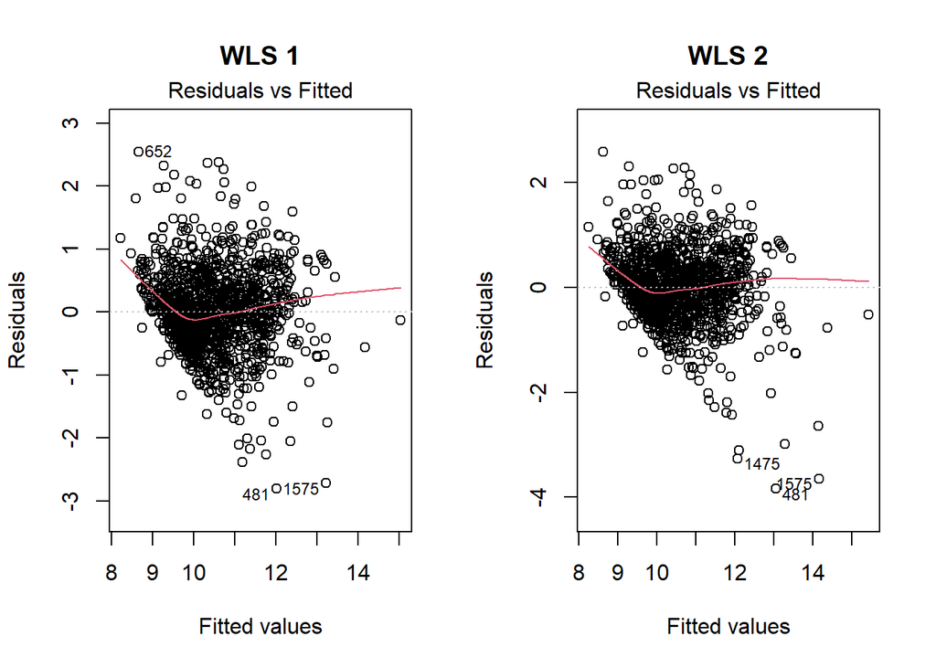

```r
par(mfrow= c(1, 2))
plot(rw.wls, which = 1, main = 'WLS 1') #WLS Model 1
plot(rw.wls2, which = 1, main = 'WLS 2') #WLS Model 2
```

As we can see from the comparison above, the variance in the second WLS model is closer to being constant. We, therefore, perform similar iterations until we reach the optimal point.

```r
lm.resid3<-lm(abs(rw.wls2$residuals)~fixed.acidity+residual.sugar+density+pH+sulphates,data=rw.new)

summary(lm.resid3)
```

```
##
## Call:
## lm(formula = abs(rw.wls2$residuals) ~ fixed.acidity + residual.sugar +
##     density + pH + sulphates, data = rw.new)
##
## Residuals:
##      Min       1Q   Median       3Q      Max
## -1.14262 -0.26064 -0.05918  0.19563  2.10561
##
## Coefficients:
##                  Estimate Std. Error t value Pr(>|t|)
## (Intercept)     28.384425   7.494887   3.787 0.000158 ***
## fixed.acidity    0.070346   0.010002   7.033 2.98e-12 ***
## residual.sugar   0.158792   0.007483  21.221  < 2e-16 ***
## density        -30.359989   7.645795  -3.971 7.48e-05 ***
## pH               0.382837   0.088554   4.323 1.63e-05 ***
## sulphates        0.141516   0.058360   2.425 0.015424 *
## ---
## Signif. codes:  0 '***' 0.001 '**' 0.01 '*' 0.05 '.' 0.1 ' ' 1
##
## Residual standard error: 0.3858 on 1593 degrees of freedom
## Multiple R-squared:  0.2543, Adjusted R-squared:  0.252
## F-statistic: 108.7 on 5 and 1593 DF,  p-value: < 2.2e-16
```

```r
rw.new$weight3<-1/(lm.resid3$fitted.values)^2

rw.wls3<-lm(alcohol~fixed.acidity+volatile.acidity+residual.sugar+citric.acid+chlorides+total.sulfur.dioxide+density+pH+sulphates,data=rw.new,weights=weight3)
summary(rw.wls3)
```

```
##
## Call:
## lm(formula = alcohol ~ fixed.acidity + volatile.acidity + residual.sugar +
##     citric.acid + chlorides + total.sulfur.dioxide + density +
##     pH + sulphates, data = rw.new, weights = weight3)
##
## Weighted Residuals:
##     Min      1Q  Median      3Q     Max
## -4.5806 -0.9013 -0.0890  0.8251  6.0945
##
## Coefficients:
##                        Estimate Std. Error t value Pr(>|t|)
## (Intercept)           6.427e+02  1.140e+01  56.388  < 2e-16 ***
## fixed.acidity         5.437e-01  1.841e-02  29.530  < 2e-16 ***
## volatile.acidity     -3.255e-02  9.509e-02  -0.342 0.732182
## residual.sugar        5.254e-01  2.285e-02  22.987  < 2e-16 ***
## citric.acid           4.375e-01  1.171e-01   3.735 0.000194 ***
## chlorides            -1.127e+00  3.078e-01  -3.663 0.000258 ***
## total.sulfur.dioxide -1.767e-03  4.421e-04  -3.998 6.69e-05 ***
## density              -6.526e+02  1.168e+01 -55.869  < 2e-16 ***
## pH                    3.523e+00  1.272e-01  27.708  < 2e-16 ***
## sulphates             1.264e+00  8.958e-02  14.107  < 2e-16 ***
## ---
## Signif. codes:  0 '***' 0.001 '**' 0.01 '*' 0.05 '.' 0.1 ' ' 1
##
## Residual standard error: 1.31 on 1589 degrees of freedom
## Multiple R-squared:  0.7261, Adjusted R-squared:  0.7245
## F-statistic:   468 on 9 and 1589 DF,  p-value: < 2.2e-16
```

Let’s see the plot improvement:

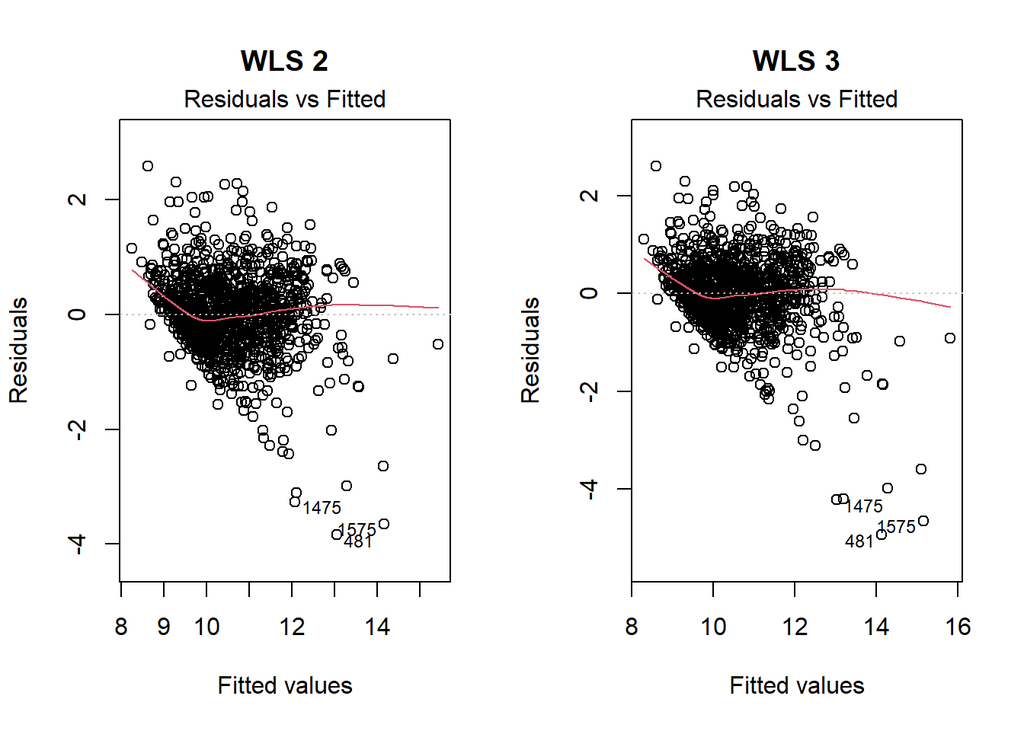

```r
par(mfrow = c(1, 2))
plot(rw.wls2, which = 1, main = 'WLS 2') #WLS Model 2
plot(rw.wls3, which = 1, main = 'WLS 3') #WLS Model 3
```

```r
lm.resid4<-lm(abs(rw.wls3$residuals)~fixed.acidity+residual.sugar+density+pH+sulphates,data=rw.new)

rw.new$weight4<-1/(lm.resid4$fitted.values)^2
summary(lm.resid4)
```

```
##
## Call:
## lm(formula = abs(rw.wls3$residuals) ~ fixed.acidity + residual.sugar +
##     density + pH + sulphates, data = rw.new)
##
## Residuals:
##      Min       1Q   Median       3Q      Max
## -1.29833 -0.25429 -0.05677  0.18977  2.16115
##
## Coefficients:
##                  Estimate Std. Error t value Pr(>|t|)
## (Intercept)     35.362450   7.555163   4.681 3.10e-06 ***
## fixed.acidity    0.060405   0.010082   5.991 2.57e-09 ***
## residual.sugar   0.231125   0.007543  30.641  < 2e-16 ***
## density        -37.175356   7.707284  -4.823 1.55e-06 ***
## pH               0.304897   0.089266   3.416 0.000652 ***
## sulphates        0.120954   0.058829   2.056 0.039943 *
## ---
## Signif. codes:  0 '***' 0.001 '**' 0.01 '*' 0.05 '.' 0.1 ' ' 1
##
## Residual standard error: 0.3889 on 1593 degrees of freedom
## Multiple R-squared:  0.3975, Adjusted R-squared:  0.3957
## F-statistic: 210.2 on 5 and 1593 DF,  p-value: < 2.2e-16
```

```r
rw.wls4<-lm(alcohol~fixed.acidity+volatile.acidity+residual.sugar+citric.acid+chlorides+total.sulfur.dioxide+density+pH+sulphates,data=rw.new,weights=weight4)

summary(rw.wls4)
```

```
##
## Call:
## lm(formula = alcohol ~ fixed.acidity + volatile.acidity + residual.sugar +
##     citric.acid + chlorides + total.sulfur.dioxide + density +
##     pH + sulphates, data = rw.new, weights = weight4)
##
## Weighted Residuals:
##     Min      1Q  Median      3Q     Max
## -5.2887 -0.9112 -0.0997  0.8351  7.1021
##
## Coefficients:
##                        Estimate Std. Error t value Pr(>|t|)
## (Intercept)           6.401e+02  1.113e+01  57.524  < 2e-16 ***
## fixed.acidity         5.273e-01  1.764e-02  29.891  < 2e-16 ***
## volatile.acidity     -7.387e-02  9.260e-02  -0.798 0.425112
## residual.sugar        6.061e-01  2.599e-02  23.321  < 2e-16 ***
## citric.acid           3.824e-01  1.145e-01   3.339 0.000860 ***
## chlorides            -1.104e+00  2.886e-01  -3.827 0.000135 ***
## total.sulfur.dioxide -1.621e-03  4.390e-04  -3.693 0.000229 ***
## density              -6.496e+02  1.140e+01 -56.999  < 2e-16 ***
## pH                    3.384e+00  1.230e-01  27.515  < 2e-16 ***
## sulphates             1.229e+00  8.590e-02  14.305  < 2e-16 ***
## ---
## Signif. codes:  0 '***' 0.001 '**' 0.01 '*' 0.05 '.' 0.1 ' ' 1
##
## Residual standard error: 1.354 on 1589 degrees of freedom
## Multiple R-squared:  0.7269, Adjusted R-squared:  0.7254
## F-statistic:   470 on 9 and 1589 DF,  p-value: < 2.2e-16
```

The $R^2$ for the 4th WLS model is slightly higher than the previous model. However, we are more concerned about the variance of the residuals. Let’s compare it with the previous model. ### Homoscedasticity:

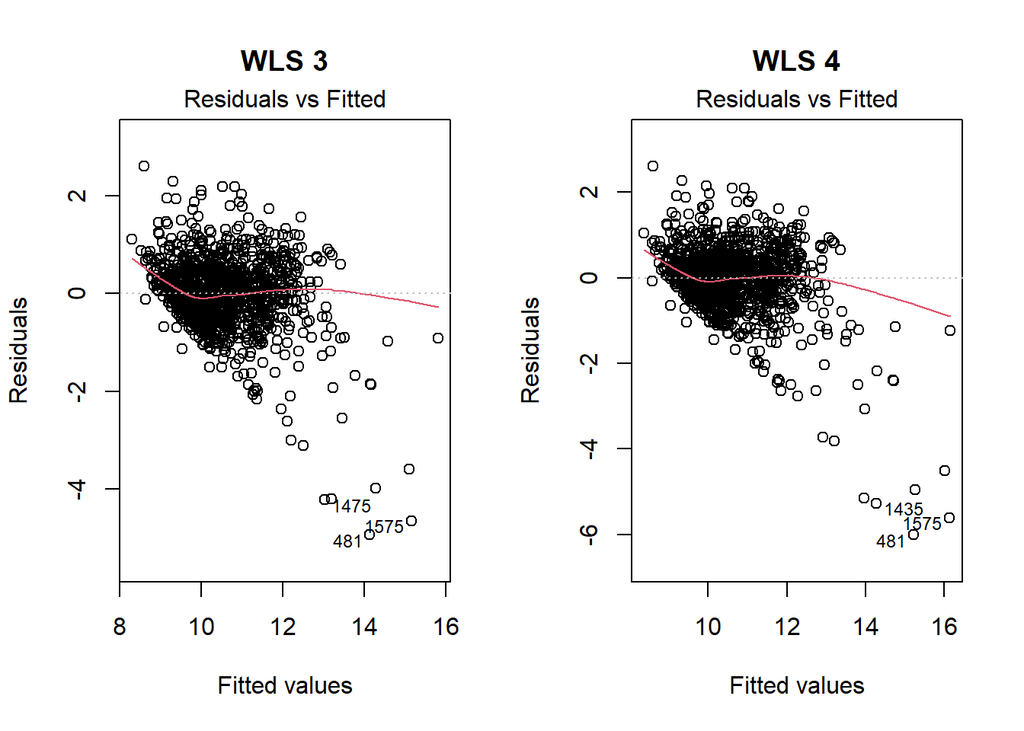

```r
par(mfrow = c(1, 2))
plot(rw.wls3, which = 1, main = 'WLS 3') #WLS Model 3
plot(rw.wls4, which = 1, main = 'WLS 4') #WLS Model 4
```

As we can see that our curve is getting away from the zero line for higher fitted values. Although none of the models makes the variance become constant, the model WLS3 appears better than the other in terms of constant variance. Since there is no significant improvement after 3 iterations, we may stop here. Comparing it with the first WLS model, we can see an increase in the coefficient of distribution, $R^2$ and the reduction in the standard error of our estimates. However, as we have changed our model, let’s check the other assumptions:

### Normality:

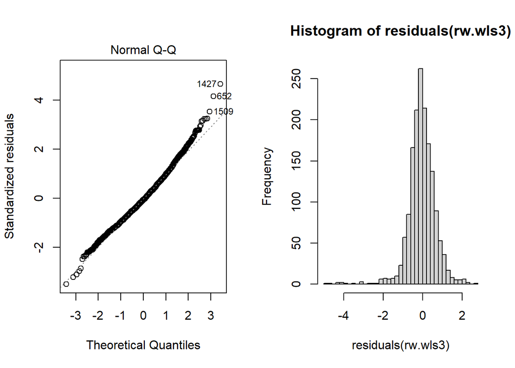

```r
par(mfrow = c(1, 2))
plot(rw.wls3, which = 2)
hist(residuals(rw.wls3), breaks = 40)
```

```r
ks.test(residuals(rw.wls3), y= pnorm)
```

```
##
##  One-sample Kolmogorov-Smirnov test
##
## data:  residuals(rw.wls3)
## D = 0.14085, p-value < 2.2e-16
## alternative hypothesis: two-sided
```

As expected, the p-value is much less than 0.05 and therefore, we may reject the null hypothesis that the errors are normal.

### Linearity:

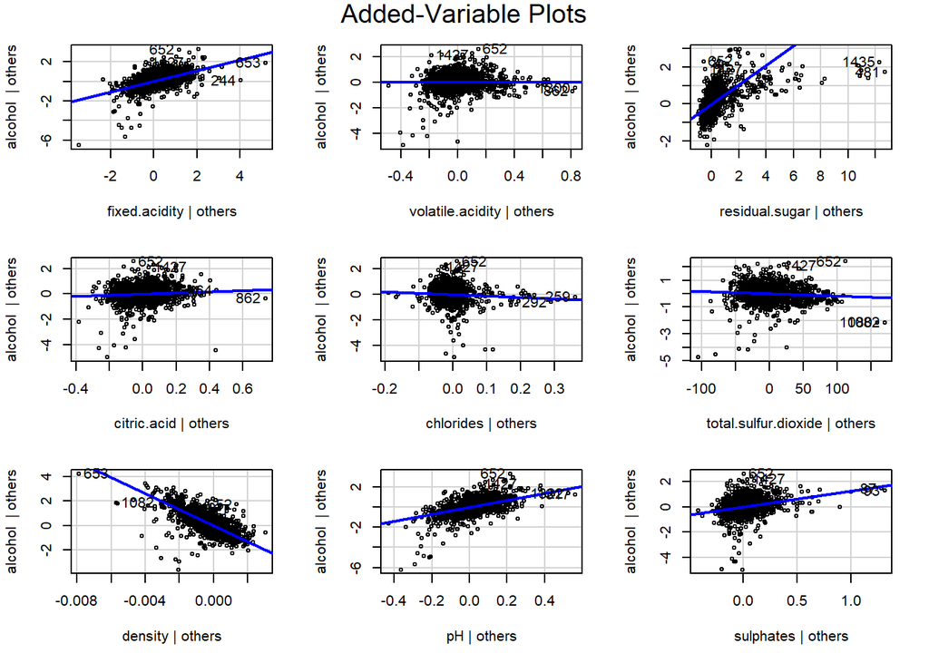

```r
avPlots(rw.wls3)
```

The added variables plot show linear trend with observations evenly scattered around the line. We may therefore, conclude that the response has a linear relationship with the predictors.

## Step 11: Weighted Least Squares for transformed response.

We can do a similar iterative WLS on the transformed model.

The summary of regression of absolute residuals on all predictors shows some insignificant predictors like `free.sulfur.dioxide` and `volatile.acidity`. Gradually removing them and refitting the model, we get the following:

```r
lm.res = lm(abs(residuals(rw.trans.reduced)) ~ fixed.acidity+residual.sugar+density+pH, data = rw.new)
summary(lm.res)
```

```
##
## Call:
## lm(formula = abs(residuals(rw.trans.reduced)) ~ fixed.acidity +
##     residual.sugar + density + pH, data = rw.new)
##
## Residuals:
##        Min         1Q     Median         3Q        Max
## -0.0030590 -0.0011372 -0.0002669  0.0008966  0.0075652
##
## Coefficients:
##                  Estimate Std. Error t value Pr(>|t|)
## (Intercept)    -1.044e-01  2.978e-02  -3.506 0.000467 ***
## fixed.acidity   1.751e-04  3.981e-05   4.398 1.16e-05 ***
## residual.sugar  1.293e-04  2.976e-05   4.344 1.49e-05 ***
## density         1.017e-01  3.036e-02   3.350 0.000827 ***
## pH              9.679e-04  3.502e-04   2.763 0.005785 **
## ---
## Signif. codes:  0 '***' 0.001 '**' 0.01 '*' 0.05 '.' 0.1 ' ' 1
##
## Residual standard error: 0.001536 on 1594 degrees of freedom
## Multiple R-squared:  0.08361,    Adjusted R-squared:  0.08131
## F-statistic: 36.36 on 4 and 1594 DF,  p-value: < 2.2e-16
```

Now, we set the weights and fit a WLS model on all the predictors as follows:

```r
rw.new$trans_weight = 1/(lm.res$fitted.values)^2
rw.tw.full = lm(alc_trans ~ fixed.acidity+volatile.acidity+free.sulfur.dioxide+citric.acid+residual.sugar+chlorides+total.sulfur.dioxide+density+pH+sulphates, data = rw.new, weights = trans_weight)
summary(rw.tw.full)
```

```
##
## Call:
## lm(formula = alc_trans ~ fixed.acidity + volatile.acidity + free.sulfur.dioxide +
##     citric.acid + residual.sugar + chlorides + total.sulfur.dioxide +
##     density + pH + sulphates, data = rw.new, weights = trans_weight)
##
## Weighted Residuals:
##     Min      1Q  Median      3Q     Max
## -4.1679 -0.8179  0.0148  0.8391  4.8314
##
## Coefficients:
##                        Estimate Std. Error t value Pr(>|t|)
## (Intercept)          -2.471e+00  4.427e-02 -55.810  < 2e-16 ***
## fixed.acidity        -2.209e-03  8.146e-05 -27.111  < 2e-16 ***
## volatile.acidity     -1.754e-04  4.240e-04  -0.414    0.679
## free.sulfur.dioxide  -1.330e-07  7.582e-06  -0.018    0.986
## citric.acid          -2.107e-03  5.204e-04  -4.048 5.41e-05 ***
## residual.sugar       -1.403e-03  6.321e-05 -22.195  < 2e-16 ***
## chlorides             6.302e-03  1.415e-03   4.453 9.05e-06 ***
## total.sulfur.dioxide  1.208e-05  2.468e-06   4.895 1.08e-06 ***
## density               2.583e+00  4.554e-02  56.727  < 2e-16 ***
## pH                   -1.468e-02  5.435e-04 -27.009  < 2e-16 ***
## sulphates            -5.317e-03  3.694e-04 -14.393  < 2e-16 ***
## ---
## Signif. codes:  0 '***' 0.001 '**' 0.01 '*' 0.05 '.' 0.1 ' ' 1
##
## Residual standard error: 1.264 on 1588 degrees of freedom
## Multiple R-squared:  0.7536, Adjusted R-squared:  0.7521
## F-statistic: 485.8 on 10 and 1588 DF,  p-value: < 2.2e-16
```

Upon checking for the statistical significance of the predictors, we find two predictors, `free.sulfur.dioxide` and `volatile.acidity` as insignificant. Since we have ruled out any collinearity in the model and the permutation tests give almost same results, we can drop these two variables and refit the model.

```r
rw.new$trans_weight = 1/(lm.res$fitted.values)^2
rw.tw = lm(alc_trans ~ fixed.acidity+citric.acid+residual.sugar+chlorides+total.sulfur.dioxide+density+pH+sulphates, data = rw.new, weights = trans_weight)
summary(rw.tw)
```

```
##
## Call:
## lm(formula = alc_trans ~ fixed.acidity + citric.acid + residual.sugar +
##     chlorides + total.sulfur.dioxide + density + pH + sulphates,
##     data = rw.new, weights = trans_weight)
##
## Weighted Residuals:
##     Min      1Q  Median      3Q     Max
## -4.1498 -0.8162  0.0182  0.8383  4.8431
##
## Coefficients:
##                        Estimate Std. Error t value Pr(>|t|)
## (Intercept)          -2.468e+00  4.347e-02 -56.776  < 2e-16 ***
## fixed.acidity        -2.212e-03  8.065e-05 -27.431  < 2e-16 ***
## citric.acid          -1.993e-03  4.363e-04  -4.568 5.31e-06 ***
## residual.sugar       -1.404e-03  6.301e-05 -22.281  < 2e-16 ***
## chlorides             6.132e-03  1.354e-03   4.528 6.39e-06 ***
## total.sulfur.dioxide  1.195e-05  1.842e-06   6.490 1.14e-10 ***
## density               2.580e+00  4.474e-02  57.679  < 2e-16 ***
## pH                   -1.471e-02  5.371e-04 -27.380  < 2e-16 ***
## sulphates            -5.291e-03  3.636e-04 -14.553  < 2e-16 ***
## ---
## Signif. codes:  0 '***' 0.001 '**' 0.01 '*' 0.05 '.' 0.1 ' ' 1
##
## Residual standard error: 1.264 on 1590 degrees of freedom
## Multiple R-squared:  0.7536, Adjusted R-squared:  0.7524
## F-statistic: 607.9 on 8 and 1590 DF,  p-value: < 2.2e-16
```

As we can see the $R^2$ for the WLS model of transformed response has significantly increased to 75% from the model without the weights which was around 65%. Besides, as expected, the standard errors of the estimates have also decreased. We continue our iterations as follows:

```r
lm.res2 = lm(abs(residuals(rw.tw)) ~ fixed.acidity+residual.sugar+density+pH, data = rw.new)
summary(lm.res2)
```

```
##
## Call:
## lm(formula = abs(residuals(rw.tw)) ~ fixed.acidity + residual.sugar +
##     density + pH, data = rw.new)
##
## Residuals:
##        Min         1Q     Median         3Q        Max
## -0.0035024 -0.0011100 -0.0002895  0.0008400  0.0085630
##
## Coefficients:
##                  Estimate Std. Error t value Pr(>|t|)
## (Intercept)    -1.011e-01  3.054e-02  -3.312 0.000949 ***
## fixed.acidity   1.856e-04  4.084e-05   4.546 5.89e-06 ***
## residual.sugar  2.902e-04  3.052e-05   9.507  < 2e-16 ***
## density         9.821e-02  3.114e-02   3.154 0.001641 **
## pH              8.756e-04  3.592e-04   2.438 0.014897 *
## ---
## Signif. codes:  0 '***' 0.001 '**' 0.01 '*' 0.05 '.' 0.1 ' ' 1
##
## Residual standard error: 0.001575 on 1594 degrees of freedom
## Multiple R-squared:  0.1399, Adjusted R-squared:  0.1377
## F-statistic:  64.8 on 4 and 1594 DF,  p-value: < 2.2e-16
```

```r
rw.new$trans_weight2 = 1/(lm.res2$fitted.values)^2
rw.tw2 = lm(alc_trans ~ fixed.acidity+citric.acid+residual.sugar+chlorides+total.sulfur.dioxide+density+pH+sulphates, data = rw.new, weights = trans_weight2)
summary(rw.tw2)
```

```
##
## Call:
## lm(formula = alc_trans ~ fixed.acidity + citric.acid + residual.sugar +
##     chlorides + total.sulfur.dioxide + density + pH + sulphates,
##     data = rw.new, weights = trans_weight2)
##
## Weighted Residuals:
##     Min      1Q  Median      3Q     Max
## -4.6712 -0.8176  0.0137  0.8537  5.2767
##
## Coefficients:
##                        Estimate Std. Error t value Pr(>|t|)
## (Intercept)          -2.554e+00  4.056e-02 -62.962  < 2e-16 ***
## fixed.acidity        -2.221e-03  7.902e-05 -28.109  < 2e-16 ***
## citric.acid          -1.932e-03  4.269e-04  -4.524 6.52e-06 ***
## residual.sugar       -1.678e-03  7.671e-05 -21.877  < 2e-16 ***
## chlorides             6.287e-03  1.311e-03   4.797 1.76e-06 ***
## total.sulfur.dioxide  1.034e-05  1.786e-06   5.792 8.36e-09 ***
## density               2.665e+00  4.185e-02  63.682  < 2e-16 ***
## pH                   -1.418e-02  5.031e-04 -28.176  < 2e-16 ***
## sulphates            -5.245e-03  3.520e-04 -14.899  < 2e-16 ***
## ---
## Signif. codes:  0 '***' 0.001 '**' 0.01 '*' 0.05 '.' 0.1 ' ' 1
##
## Residual standard error: 1.308 on 1590 degrees of freedom
## Multiple R-squared:   0.78,  Adjusted R-squared:  0.7789
## F-statistic: 704.8 on 8 and 1590 DF,  p-value: < 2.2e-16
```

Comparing the models on the basis of normality and constant variance: Let’s check the two models on the respective tests.

```r
bptest(rw.tw)
```

```
##
##  studentized Breusch-Pagan test
##
## data:  rw.tw
## BP = 199.43, df = 8, p-value < 2.2e-16
```

```r
bptest(rw.tw2)
```

[output not shown]

The p-value in both the cases is much lower than 0.05 and hence, we conclude homoscedasticity is not present.

```r
ks.test(residuals(rw.tw), y=pnorm)
```

```
##
##  One-sample Kolmogorov-Smirnov test
##
## data:  residuals(rw.tw)
## D = 0.49551, p-value < 2.2e-16
## alternative hypothesis: two-sided
```

```r
ks.test(residuals(rw.tw2), y = pnorm)
```

```
##
##  One-sample Kolmogorov-Smirnov test
##
## data:  residuals(rw.tw2)
## D = 0.49542, p-value < 2.2e-16
## alternative hypothesis: two-sided
```

Both the models fail on the Kolmogorov-Smirnov test for normality. Let’s have a look at the plots:

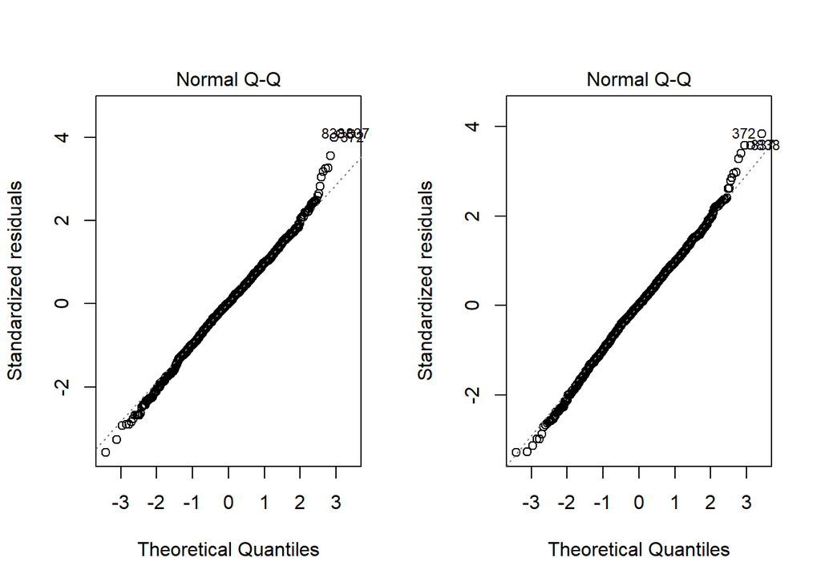

```r
par(mfrow = c(1, 2))
plot(rw.tw2, which = 2)
plot(rw.tw, which = 2)
```

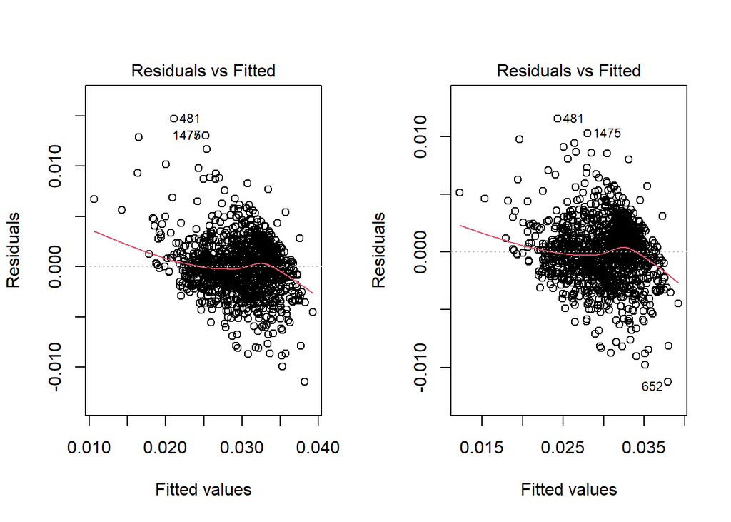

```r
par(mfrow = c(1, 2))
plot(rw.tw2, which = 1)
plot(rw.tw, which = 1)
```

There is not considerable change in the plot of residuals vs fitted values in the two models. However, the deviation from the straight line in the QQ plot of the residuals indicate that the first WLS model with transformed response, `rw.tw` is a better one. Also, since the plot showing the variance of residuals is not improving, we may stop our iterations.

### Step 12: Final Model Selection

Finally, we compare the two models, the former that we got by Weighted Least Squares method on untransformed response, and the latter that we got by WLS method on transformed response.

```r
summary(rw.wls3)
```

```
##
## Call:
## lm(formula = alcohol ~ fixed.acidity + volatile.acidity + residual.sugar +
##     citric.acid + chlorides + total.sulfur.dioxide + density +
##     pH + sulphates, data = rw.new, weights = weight3)
##
## Weighted Residuals:
##     Min      1Q  Median      3Q     Max
## -4.5806 -0.9013 -0.0890  0.8251  6.0945
##
## Coefficients:
##                        Estimate Std. Error t value Pr(>|t|)
## (Intercept)           6.427e+02  1.140e+01  56.388  < 2e-16 ***
## fixed.acidity         5.437e-01  1.841e-02  29.530  < 2e-16 ***
## volatile.acidity     -3.255e-02  9.509e-02  -0.342 0.732182
## residual.sugar        5.254e-01  2.285e-02  22.987  < 2e-16 ***
## citric.acid           4.375e-01  1.171e-01   3.735 0.000194 ***
## chlorides            -1.127e+00  3.078e-01  -3.663 0.000258 ***
## total.sulfur.dioxide -1.767e-03  4.421e-04  -3.998 6.69e-05 ***
## density              -6.526e+02  1.168e+01 -55.869  < 2e-16 ***
## pH                    3.523e+00  1.272e-01  27.708  < 2e-16 ***
## sulphates             1.264e+00  8.958e-02  14.107  < 2e-16 ***
## ---
## Signif. codes:  0 '***' 0.001 '**' 0.01 '*' 0.05 '.' 0.1 ' ' 1
##
## Residual standard error: 1.31 on 1589 degrees of freedom
## Multiple R-squared:  0.7261, Adjusted R-squared:  0.7245
## F-statistic:   468 on 9 and 1589 DF,  p-value: < 2.2e-16
```

```r
summary(rw.tw)
```

```
##
## Call:
## lm(formula = alc_trans ~ fixed.acidity + citric.acid + residual.sugar +
##     chlorides + total.sulfur.dioxide + density + pH + sulphates,
##     data = rw.new, weights = trans_weight)
##
## Weighted Residuals:
##     Min      1Q  Median      3Q     Max
## -4.1498 -0.8162  0.0182  0.8383  4.8431
##
## Coefficients:
##                        Estimate Std. Error t value Pr(>|t|)
## (Intercept)          -2.468e+00  4.347e-02 -56.776  < 2e-16 ***
## fixed.acidity        -2.212e-03  8.065e-05 -27.431  < 2e-16 ***
## citric.acid          -1.993e-03  4.363e-04  -4.568 5.31e-06 ***
## residual.sugar       -1.404e-03  6.301e-05 -22.281  < 2e-16 ***
## chlorides             6.132e-03  1.354e-03   4.528 6.39e-06 ***
## total.sulfur.dioxide  1.195e-05  1.842e-06   6.490 1.14e-10 ***
## density               2.580e+00  4.474e-02  57.679  < 2e-16 ***
## pH                   -1.471e-02  5.371e-04 -27.380  < 2e-16 ***
## sulphates            -5.291e-03  3.636e-04 -14.553  < 2e-16 ***
## ---
## Signif. codes:  0 '***' 0.001 '**' 0.01 '*' 0.05 '.' 0.1 ' ' 1
##
## Residual standard error: 1.264 on 1590 degrees of freedom
## Multiple R-squared:  0.7536, Adjusted R-squared:  0.7524
## F-statistic: 607.9 on 8 and 1590 DF,  p-value: < 2.2e-16
```

We also do the diagnostics on the two models:

#### Outliers:

WLS 3 Model:

```r
jackknife1=rstudent(rw.wls3)
n = 1599
p = 9
x=qt(.05/(2*n), n-p-1) #Significance level adjusted with Bonferroni's Correction
x
```

```
## [1] -4.176063
```

```r
sort(abs(jackknife1),decreasing =T)[1:10]
```

```
##     1427      652     1509      372      654      494      500     1132
## 4.696713 4.177351 3.547232 3.522541 3.257674 3.239182 3.239182 3.238882
##      727      428
## 3.159251 3.157502
```

Transformed WLS:

```r
jackknife2=rstudent(rw.tw)
n = 1599
p = 9
x=qt(.05/(2*n), n-p-1) #Significance level adjusted with Bonferroni's Correction
x
```

```
## [1] -4.176063
```

```r
sort(abs(jackknife2),decreasing =T)[1:10]
```

```
##      372      837      838     1115     1427     1234      652      654
## 3.859106 3.594553 3.594553 3.406906 3.299652 3.284502 3.279516 3.138935
##      494      500
## 2.996299 2.996299
```

There are no outliers in the Transformed WLS model.

#### High Infuential Points (Cook’s distance):

```r
par(mfrow = c(1, 2))
cook1 = cooks.distance(rw.wls3)
max(cook1)
```

```
## [1] 0.07597355
```

```r
halfnorm(cook1, 6, labs=as.character(1:length(cook)), ylab="Cook's distances", main = "WLS 3 Model")
cook2 = cooks.distance(rw.trans.reduced)

max(cook2)
```

```
## [1] 0.07231543
```

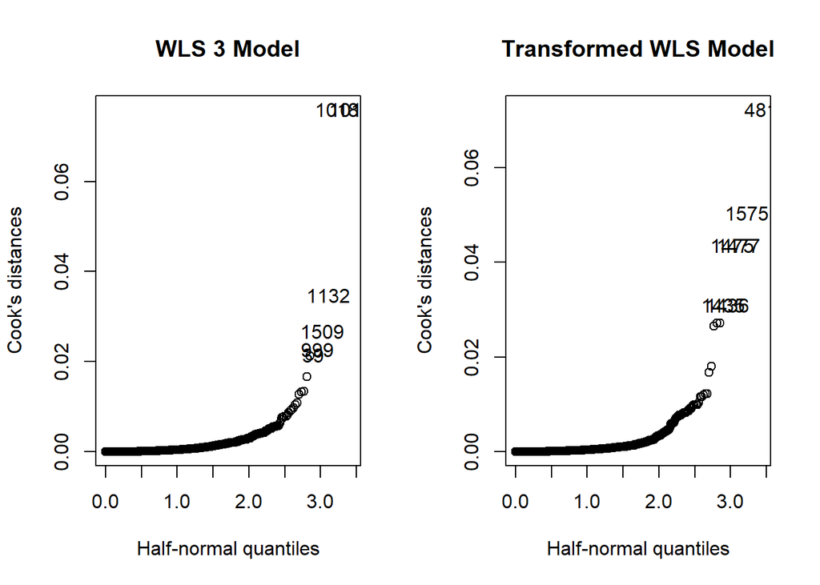

```r
halfnorm(cook2, 6, labs=as.character(1:length(cook)), ylab="Cook's distances", main = "Transformed WLS Model")
```

Thus, we can see none of the models has any High Influential points. Hence, we don’t need to drop any observation.

### Model Assumption Diagnostics:

We perform the tests for our model assumptions as follows:

#### Homoscedasticity:

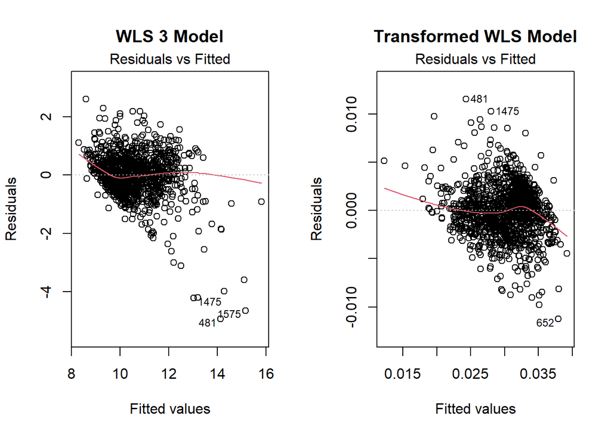

```r
par(mfrow = c(1, 2))
plot(rw.wls3, which = 1, main = "WLS 3 Model")
plot(rw.tw, which = 1, main = "Transformed WLS Model")
```

Both models show non-constant variance. But, the WLS 3 model is closer to being constant than the Transformed WLS model. Also, we test through the Breusch-Pagan test:

```r
bptest(rw.wls3)
```

```
##
##  studentized Breusch-Pagan test
##
## data:  rw.wls3
## BP = 169.31, df = 9, p-value < 2.2e-16
```

```r
bptest(rw.tw)
```

```
##
##  studentized Breusch-Pagan test
##
## data:  rw.tw
## BP = 199.43, df = 8, p-value < 2.2e-16
```

Thus, both the models fail the test.

#### Normality:

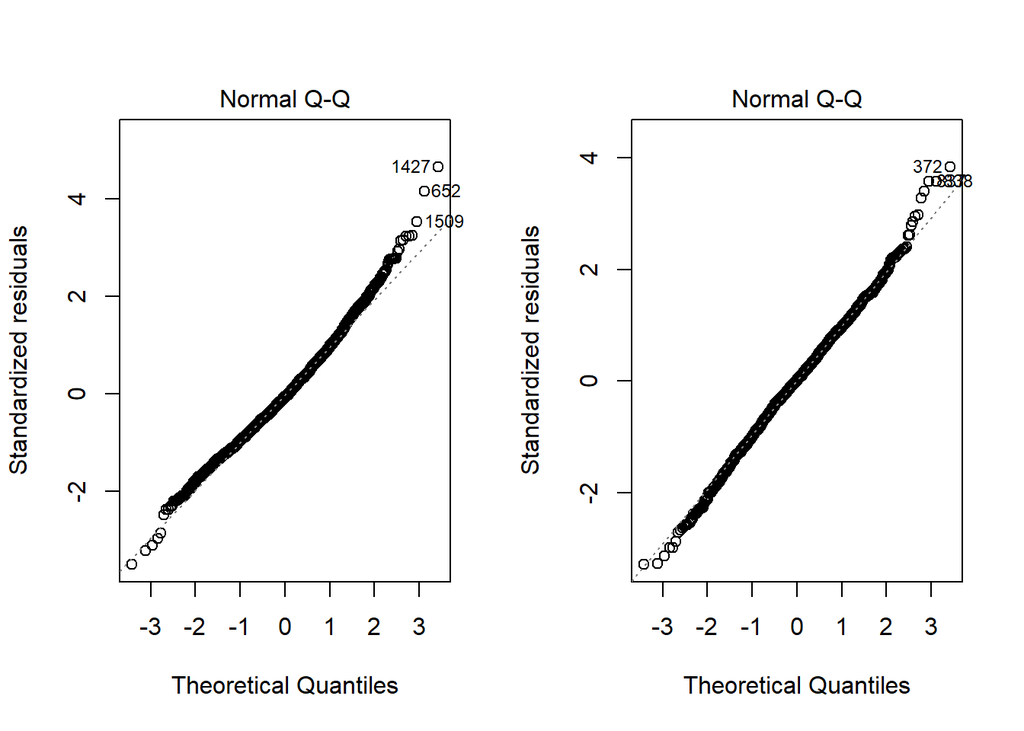

```r
par(mfrow = c(1, 2))
plot(rw.wls3, which = 2)
plot(rw.tw, which = 2)
```

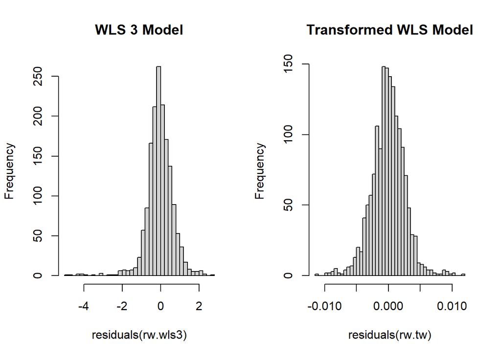

```r
par(mfrow = c(1, 2))
hist(residuals(rw.wls3),breaks = 40, main = "WLS 3 Model")
hist(residuals(rw.tw),breaks = 40, main = "Transformed WLS Model")
```

In this case, the second model, i.e. Transformed model shows better plots in terms of normality, with fewer points deviating from the straight line in the QQ plot and very less skew in the histogram. Also, we test through the Kolmogorov-Smirnov test:

```r
ks.test(residuals(rw.wls3), y=pnorm)
```

```
##
##  One-sample Kolmogorov-Smirnov test
##
## data:  residuals(rw.wls3)
## D = 0.14085, p-value < 2.2e-16
## alternative hypothesis: two-sided
```

```r
ks.test(residuals(rw.tw), y=pnorm)
```

```
##
##  One-sample Kolmogorov-Smirnov test
##
## data:  residuals(rw.tw)
## D = 0.49551, p-value < 2.2e-16
## alternative hypothesis: two-sided
```

Both the models fail the KS test. However, the QQ plot of the residuals of the Transformed WLS model, `rw.tw` shows fewer points deviating from the straight line.

#### Linearity:

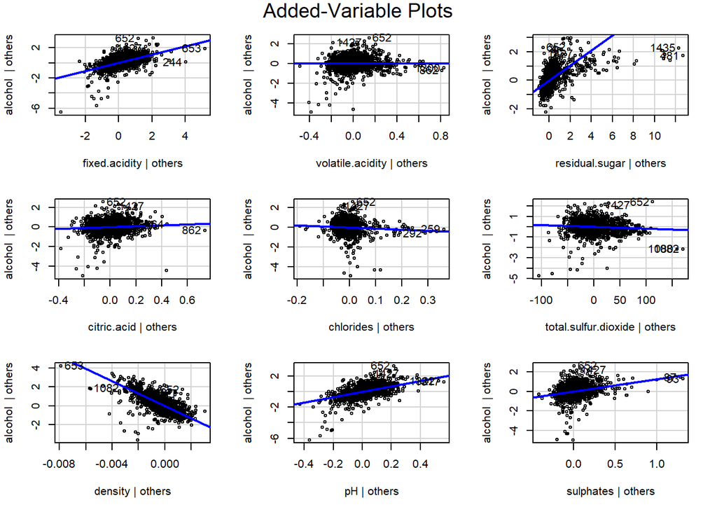

```r
avPlots(rw.wls3)
```

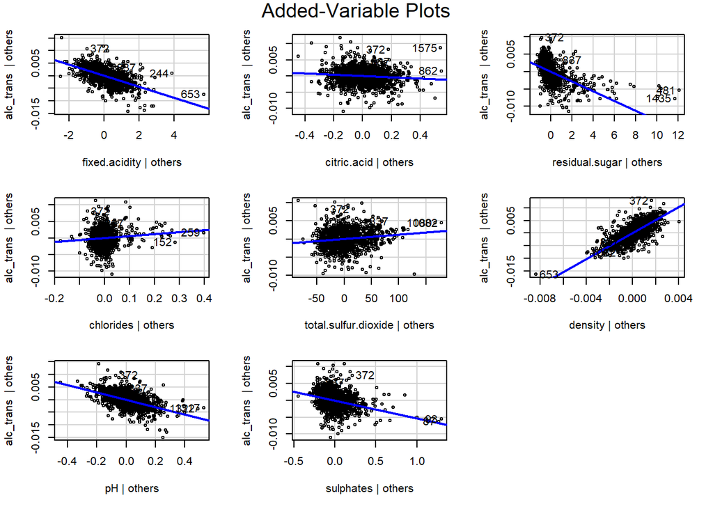

```r
avPlots(rw.tw)
```

Both models show that the relationship is, by and large, linear with the predictors.

Finally, we choose the Transformed WLS model for its performance in explaining the variation in response (greater value of $R^2$), while being a simpler model (less number of predictors) and getting residuals closer to normal distribution.

#### Summary of the final model:

```r
summary(rw.tw)
```

```
##
## Call:
## lm(formula = alc_trans ~ fixed.acidity + citric.acid + residual.sugar +
##     chlorides + total.sulfur.dioxide + density + pH + sulphates,
##     data = rw.new, weights = trans_weight)
##
## Weighted Residuals:
##     Min      1Q  Median      3Q     Max
## -4.1498 -0.8162  0.0182  0.8383  4.8431
##
## Coefficients:
##                        Estimate Std. Error t value Pr(>|t|)
## (Intercept)          -2.468e+00  4.347e-02 -56.776  < 2e-16 ***
## fixed.acidity        -2.212e-03  8.065e-05 -27.431  < 2e-16 ***
## citric.acid          -1.993e-03  4.363e-04  -4.568 5.31e-06 ***
## residual.sugar       -1.404e-03  6.301e-05 -22.281  < 2e-16 ***
## chlorides             6.132e-03  1.354e-03   4.528 6.39e-06 ***
## total.sulfur.dioxide  1.195e-05  1.842e-06   6.490 1.14e-10 ***
## density               2.580e+00  4.474e-02  57.679  < 2e-16 ***
## pH                   -1.471e-02  5.371e-04 -27.380  < 2e-16 ***
## sulphates            -5.291e-03  3.636e-04 -14.553  < 2e-16 ***
## ---
## Signif. codes:  0 '***' 0.001 '**' 0.01 '*' 0.05 '.' 0.1 ' ' 1
##
## Residual standard error: 1.264 on 1590 degrees of freedom
## Multiple R-squared:  0.7536, Adjusted R-squared:  0.7524
## F-statistic: 607.9 on 8 and 1590 DF,  p-value: < 2.2e-16
```